# Digital literacy: additional analyses

Exploratory exhibits not in the manuscript or compiled SI

Author

Kristina Aleksandrovna Pedersen, Ferdinand Geissler, Felix Hartmann, Johannes Giesecke, Macartan Humphreys, Heike Klüver

Additional analyses organized by the paper / SI section they speak to.

Output is written to `additional/` (`figs`, `tabs`, `ests`, `ggs`).

# 1 Setup

```r
# Load packages
pacman::p_load(
  forcats,
  scales,
  fixest,
  tidyverse,
  estimatr,
  haven,
  knitr,
  broom,
  ggh4x,
  ellipse,
  ggrepel,
  texreg,
  ggalluvial,
  scales,
  grf
)
```

## 1.1 Configuration

```r
setFixest_notes(FALSE)  # Suppress fixest NOTE messages
filter_10 <- TRUE
# Causal forests is slow; set TRUE once to fit/save, then FALSE to reuse ests/
RUN_FORESTS <- FALSE
pref_var <- "party_preference_"

# Edit figure labels here
strategies <-
  c("political\n(emotional)", "political\n(neutral)")

# Outputs stay out of paper/SI dirs (ests, ggs, figs, tabs)
out_root <- "additional"
est_dir <- file.path(out_root, "ests")
gg_dir  <- file.path(out_root, "ggs")
fig_dir <- file.path(out_root, "figs")
tab_dir <- file.path(out_root, "tabs")

strategy_order_article <- c(
  "political\n(emotional)",
  "political\n(neutral)",
  "entertainment"
)

# Outcomes and groups
v_outcomes <- c(
  "Like" = "videoLikep1r",
  "Share" = "videoSharep1r",
  "Bookmark" = "videoBookmarkp1r",
  "Report" = "videoCommentTickedp1r",
  "Watch Time" = "watch_percentage_",
  "Skip" = "skipped_video_"
)

l_outcomegroups <- list(
  main = c("Like", "Report", "Share", "Bookmark"),
  "_other" = c("Skip", "Watch Time")
)

# Paper-facing horizon labels (datasets remain wave_9 / wave_10)
horizon_wave_levels <- c("Wave 1", "Wave 2")

l_partisanship <- list(
  "Supporter: Yes" = 1,
  "Supporter: No" = 0,
  "All" = c(0, 1)
)

party_codes <-  c("afd", "cdu", "linke", "spd", "gruene", "fdp", "bsw")
party_names <- c("AfD", "CDU/CSU", "Linke",   "SPD",  "Grüne",  "FDP",  "BSW")
names(party_codes) <- party_names
names(party_names) <- party_codes

# texreg: *** / ** / * map to these upper bounds (not 0.001/0.01/0.05)
texreg_stars <- c(0.01, 0.05, 0.10)
```

## 1.2 Helper functions

```r
replace_file <- function(from, to) {
  if (file.exists(to) && unlink(to) != 0) {
    file.rename(to, paste0(to, ".old"))
  }
  if (!isTRUE(file.rename(from, to))) {
    file.copy(from, to, overwrite = TRUE)
    unlink(from)
  }
}

write_fig <- function(stem, estimates, plot, width = NA, height = NA) {
  est_path <- file.path(est_dir, paste0(stem, ".rds"))
  gg_path  <- file.path(gg_dir, paste0(stem, ".rds"))
  pdf_path <- file.path(fig_dir, paste0(stem, ".pdf"))
  tmp_near <- function(path) file.path(dirname(path), paste0(".", basename(path), ".tmp"))
  write_rds(estimates, tmp_near(est_path))
  replace_file(tmp_near(est_path), est_path)
  write_rds(plot, tmp_near(gg_path))
  replace_file(tmp_near(gg_path), gg_path)
  tmp_pdf <- tmp_near(pdf_path)
  save_pdf <- function(dev) {
    if (is.na(width) && is.na(height)) {
      ggsave(tmp_pdf, plot, device = dev)
    } else {
      ggsave(tmp_pdf, plot, device = dev, width = width, height = height)
    }
  }
  tryCatch(save_pdf(cairo_pdf), error = function(e) save_pdf(pdf))
  replace_file(tmp_pdf, pdf_path)
  print(plot)
}
```

# 2 Data

```r
datasets <- list(
  wave_9  = read_rds("data/wave_9.rds"),
  wave_10 = read_rds("data/wave_10.rds"))

df_w9_w10  <- read_rds("data/df_w9_w10.rds")|>
  mutate(citysize = as.numeric(citysize))

comments_df <-read.csv("data/comment_classification.csv")

# covariates

# ---- English labels for covariates (matches prepared data after tolower) ----
labels_en <- c(
  # Basics
  alter         = "Age",
  gender_female = "Female (vs male)",
  citysize      = "City size",

  # Region binaries and state indicators
  east = "East (vs West)",
  state_baden_wuerttemberg    = "State: Baden-Württemberg",
  state_bayern                = "State: Bavaria",
  state_berlin                = "State: Berlin",
  state_brandenburg           = "State: Brandenburg",
  state_bremen                = "State: Bremen",
  state_hamburg               = "State: Hamburg",
  state_hessen                = "State: Hesse",
  state_mecklenburg_vorpommern = "State: Mecklenburg–Western Pomerania",
  state_niedersachsen         = "State: Lower Saxony",
  state_nordrhein_westfalen   = "State: North Rhine-Westphalia",
  state_rheinland_pfalz       = "State: Rhineland-Palatinate",
  state_saarland              = "State: Saarland",
  state_sachsen               = "State: Saxony",
  state_sachsen_anhalt        = "State: Saxony-Anhalt",
  state_schleswig_holstein    = "State: Schleswig-Holstein",
  state_thueringen            = "State: Thuringia",

  # Urbanization indicators
  urban_ballungsraum  = "Urban: metropolitan area",
  urban_stadtregion   = "Urban: city region",
  urban_mittelzentrum = "Urban: medium-sized center",
  urban_high          = "High urbanization",

  # Social-media use
  video_userfacebook       = "Uses Facebook",
  video_usertiktok         = "Uses TikTok",
  video_usersnapchat       = "Uses Snapchat",
  video_userpinterest      = "Uses Pinterest",
  video_userx_ehem_twitter = "Uses X/Twitter",
  video_usertwitch         = "Uses Twitch",

  # Political attitudes
  politikinteresse = "Political interest",
  lr               = "Left–right ideology",

  # Party regarded as competent
  competence_cdu_csu = "Competent party: CDU/CSU",
  competence_spd     = "Competent party: SPD",
  competence_afd     = "Competent party: AfD",
  competence_greens  = "Competent party: Greens",
  competence_fdp     = "Competent party: FDP",
  competence_left    = "Competent party: The Left",
  competence_bsw     = "Competent party: BSW",

  # Party identification at wave 9
  party_id_w9_cdu    = "Party ID: CDU/CSU",
  party_id_w9_spd    = "Party ID: SPD",
  party_id_w9_afd    = "Party ID: AfD",
  party_id_w9_gruene = "Party ID: Greens",
  party_id_w9_fdp    = "Party ID: FDP",
  party_id_w9_linke  = "Party ID: The Left",
  party_id_w9_bsw    = "Party ID: BSW",

  # Pre-treatment propensities to vote
  ptv_w9_pre_cdu    = "PTV CDU/CSU (pre)",
  ptv_w9_pre_spd    = "PTV SPD (pre)",
  ptv_w9_pre_linke  = "PTV The Left (pre)",
  ptv_w9_pre_gruene = "PTV Greens (pre)",
  ptv_w9_pre_fdp    = "PTV FDP (pre)",
  ptv_w9_pre_afd    = "PTV AfD (pre)",
  ptv_w9_pre_bsw    = "PTV BSW (pre)",

  # Other attitudes
  prior_performance_general_2 = "Government performance (prior)",
  solidaritat                 = "Solidarity",
  sozialer_zusammenhalt       = "Social cohesion",
  migration                   = "Immigration attitudes",

  # TikTok-specific indicators
  tiktok_user_yes      = "Current TikTok user",
  tiktok_user_no       = "Not a TikTok user",
  tiktok_potential_yes = "Open to getting a TikTok account",
  tiktok_potential_no  = "Not open to getting a TikTok account",

  # Employment status
  employment_fulltime         = "Employment: full-time",
  employment_parttime         = "Employment: part-time",
  employment_marginal         = "Employment: marginal/irregular",
  employment_training_service = "Employment: training/service",
  employment_not_working      = "Not currently employed",

  # Occupational position
  occupation_worker         = "Occupation: worker",
  occupation_employee       = "Occupation: employee",
  occupation_public_service = "Occupation: public service",
  occupation_self_employed  = "Occupation: self-employed",

  # Education
  school_education_level = "School education level",
  vocational_basic       = "Vocational education: basic",
  vocational_advanced    = "Vocational education: advanced",
  vocational_other       = "Vocational education: other",
  vocational_none        = "No vocational qualification",

  # Household and demographic characteristics
  eigene_kinder                 = "Has children",
  haushaltsgrobe                = "Household size",
  migrationshintergrund_eltern  = "Parental migration background",
  haushaltseinkommen            = "Household income"
)
```

# 3 Paper: secondary analyses (attention)

Watch-time / liking / reporting / bookmarking associations. These were drafted for the SI relations section and are not in the compiled SI. # Exploratory: Watch / bookmark vs liking / reporting (row-level; type × Wave 1/Wave 2)

**Descriptive fits** (not causal). Unit = **video–respondent row**. Samples = Wave 1 (`wave_9`) and Wave 2 (`wave_10`) engagement, all three content types in `strategy_order_article` (emotional, neutral, entertainment)—same span as pooled engagement ATEs (`f_I`). Facets: **rows** = video type; **cols** = Wave 1 | Wave 2 (no AfD split). Within each panel: treatment-colored fits (no dense row points) plus summary dots at (mean x, mean y) by arm. **(1)** Watch → like: `geom_smooth()`; x = `watch_percentage_`; y = `videoLikep1r`. **(2)** Watch → report: same structure; y = `videoCommentTickedp1r`. **(3)** Bookmark → like: conditional liking shares $P(\text{like}\mid\text{bookmark}\in\{0,1\})$ with cluster-robust 95% CIs by `ID` (points + error bars + thin connector by treatment), plus darker mean dots at $(\bar b, \bar \ell)$; slight $x$ dodge on the conditional series only; x = `videoBookmarkp1r`. Stems: `fig_watch_like_short_long`, `fig_watch_report_short_long`, `fig_bookmark_like_short_long`. Replaces retired `fig_watch_like_all_afd`, `fig_watch_report_all_afd`, `fig_bookmark_like_all_afd`, `fig_bookmark_like_all_afd_longterm`, and earlier type×treatment / person-average versions.

```r
treat_cols <- c(Control = "#4C78A8", Treatment = "#E45756")
treat_cols_dark <- c(Control = "#2B4C6F", Treatment = "#A33A39")
horizon_levels <- horizon_wave_levels

prep_watch_like <- function(dat, horizon) {
  dat |>
    filter(strategy_2 %in% strategy_order_article) |>
    transmute(
      ID = as.character(ID),
      strategy = factor(as.character(strategy_2), levels = strategy_order_article),
      treatment = factor(
        ifelse(workshop_Treatment == 1, "Treatment", "Control"),
        levels = c("Control", "Treatment")
      ),
      watch = as.numeric(watch_percentage_),
      like = as.numeric(videoLikep1r),
      horizon = factor(horizon, levels = horizon_levels)
    ) |>
    filter(is.finite(watch), is.finite(like), !is.na(strategy), !is.na(treatment))
}

df_watch_like_row <- bind_rows(
  prep_watch_like(datasets$wave_9, "Wave 1"),
  prep_watch_like(datasets$wave_10, "Wave 2")
)

df_watch_like_means <- df_watch_like_row |>
  group_by(strategy, horizon, treatment) |>
  summarise(
    watch = mean(watch, na.rm = TRUE),
    like = mean(like, na.rm = TRUE),
    n = n(),
    .groups = "drop"
  )

cat(
  "Watch time vs liking (row-level; Wave 1 | Wave 2; no AfD panels)\n",
  "  N rows (Wave 1): ", sum(df_watch_like_row$horizon == "Wave 1"),
  "  (unique IDs: ",
  dplyr::n_distinct(df_watch_like_row$ID[df_watch_like_row$horizon == "Wave 1"]),
  ")\n",
  "  N rows (Wave 2): ", sum(df_watch_like_row$horizon == "Wave 2"),
  "  (unique IDs: ",
  dplyr::n_distinct(df_watch_like_row$ID[df_watch_like_row$horizon == "Wave 2"]),
  ")\n",
  sep = ""
)
```

```
Watch time vs liking (row-level; Wave 1 | Wave 2; no AfD panels)
  N rows (Wave 1): 132944  (unique IDs: 4436)
  N rows (Wave 2): 121877  (unique IDs: 3359)
```

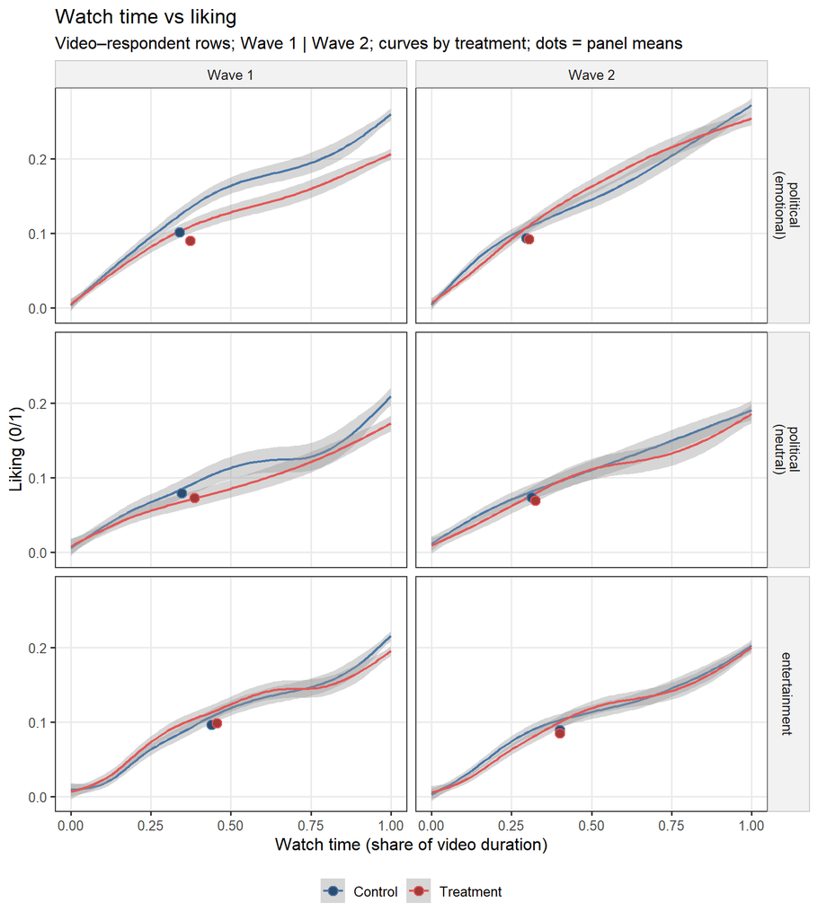

```r
fig_watch_like_short_long <- ggplot(
  df_watch_like_row,
  aes(x = watch, y = like, color = treatment)
) +
  geom_smooth(se = TRUE, linewidth = 0.85) +
  geom_point(
    data = df_watch_like_means,
    aes(x = watch, y = like, color = treatment, fill = treatment),
    shape = 21,
    size = 2.8,
    stroke = 0.7,
    inherit.aes = FALSE
  ) +
  scale_color_manual(values = treat_cols, name = NULL) +
  scale_fill_manual(values = treat_cols_dark, name = NULL) +
  facet_grid(rows = vars(strategy), cols = vars(horizon)) +
  labs(
    title = "Watch time vs liking",
    subtitle = "Video–respondent rows; Wave 1 | Wave 2; curves by treatment; dots = panel means",
    x = "Watch time (share of video duration)",
    y = "Liking (0/1)"
  ) +
  theme_bw(base_size = 12) +
  theme(
    panel.grid.minor = element_blank(),
    strip.background = element_rect(fill = "grey95", color = "grey80"),
    legend.position = "bottom"
  )

write_fig(
  stem = "fig_watch_like_short_long",
  estimates = list(rows = df_watch_like_row, means = df_watch_like_means),
  plot = fig_watch_like_short_long,
  width = 8,
  height = 9
)
```

**Companion:** same type × Wave 1/Wave 2 facet / treatment-color / mean-dot / `geom_smooth()` structure; **x** = watch time; **y** = reporting (`videoCommentTickedp1r`, 0/1).

```r
prep_watch_report <- function(dat, horizon) {
  dat |>
    filter(strategy_2 %in% strategy_order_article) |>
    transmute(
      ID = as.character(ID),
      strategy = factor(as.character(strategy_2), levels = strategy_order_article),
      treatment = factor(
        ifelse(workshop_Treatment == 1, "Treatment", "Control"),
        levels = c("Control", "Treatment")
      ),
      watch = as.numeric(watch_percentage_),
      report = as.numeric(videoCommentTickedp1r),
      horizon = factor(horizon, levels = horizon_levels)
    ) |>
    filter(is.finite(watch), is.finite(report), !is.na(strategy), !is.na(treatment))
}

df_watch_report_row <- bind_rows(
  prep_watch_report(datasets$wave_9, "Wave 1"),
  prep_watch_report(datasets$wave_10, "Wave 2")
)

df_watch_report_means <- df_watch_report_row |>
  group_by(strategy, horizon, treatment) |>
  summarise(
    watch = mean(watch, na.rm = TRUE),
    report = mean(report, na.rm = TRUE),
    n = n(),
    .groups = "drop"
  )

cat(
  "Watch time vs reporting (row-level; Wave 1 | Wave 2; no AfD panels)\n",
  "  N rows (Wave 1): ", sum(df_watch_report_row$horizon == "Wave 1"),
  "  (unique IDs: ",
  dplyr::n_distinct(df_watch_report_row$ID[df_watch_report_row$horizon == "Wave 1"]),
  ")\n",
  "  N rows (Wave 2): ", sum(df_watch_report_row$horizon == "Wave 2"),
  "  (unique IDs: ",
  dplyr::n_distinct(df_watch_report_row$ID[df_watch_report_row$horizon == "Wave 2"]),
  ")\n",
  sep = ""
)
```

```
Watch time vs reporting (row-level; Wave 1 | Wave 2; no AfD panels)
  N rows (Wave 1): 132944  (unique IDs: 4436)
  N rows (Wave 2): 121877  (unique IDs: 3359)
```

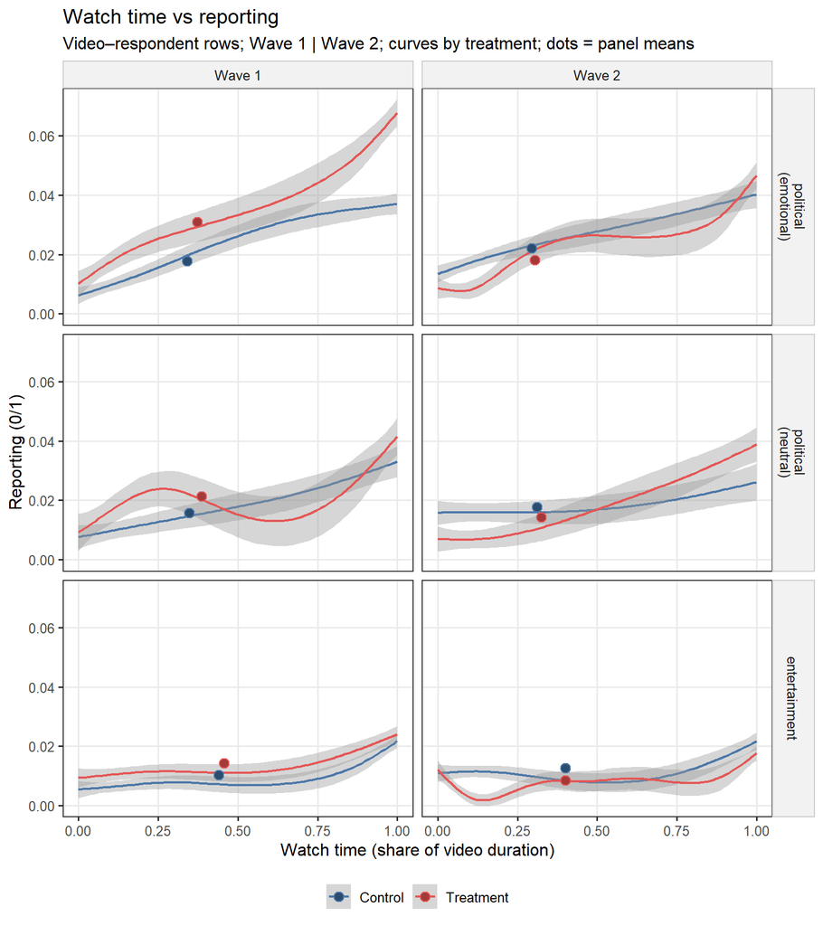

```r
fig_watch_report_short_long <- ggplot(
  df_watch_report_row,
  aes(x = watch, y = report, color = treatment)
) +
  geom_smooth(se = TRUE, linewidth = 0.85) +
  geom_point(
    data = df_watch_report_means,
    aes(x = watch, y = report, color = treatment, fill = treatment),
    shape = 21,
    size = 2.8,
    stroke = 0.7,
    inherit.aes = FALSE
  ) +
  scale_color_manual(values = treat_cols, name = NULL) +
  scale_fill_manual(values = treat_cols_dark, name = NULL) +
  facet_grid(rows = vars(strategy), cols = vars(horizon)) +
  labs(
    title = "Watch time vs reporting",
    subtitle = "Video–respondent rows; Wave 1 | Wave 2; curves by treatment; dots = panel means",
    x = "Watch time (share of video duration)",
    y = "Reporting (0/1)"
  ) +
  theme_bw(base_size = 12) +
  theme(
    panel.grid.minor = element_blank(),
    strip.background = element_rect(fill = "grey95", color = "grey80"),
    legend.position = "bottom"
  )

write_fig(
  stem = "fig_watch_report_short_long",
  estimates = list(rows = df_watch_report_row, means = df_watch_report_means),
  plot = fig_watch_report_short_long,
  width = 8,
  height = 9
)
```

**Companion:** same type × Wave 1/Wave 2 facet and treatment colors; **x** = bookmarking (`videoBookmarkp1r`, 0/1), **y** = liking. For each panel × treatment × bookmark ∈ {0,1}, plot $P(\text{like}\mid\text{bookmark})$ from `estimatr::lm_robust(like ~ 1, clusters = ID)` with 95% CIs; thin line joins bookmark 0→1 within arm (slight $x$ dodge by treatment). Darker mean dots at $(\bar b, \bar \ell)$ per arm, with a thin Control–Treatment segment. No hollow rings / cell-share circles. Wave 1 and Wave 2 are columns of one figure (no separate Wave 2-only export).

```r
prep_bookmark_like <- function(dat, horizon) {
  dat |>
    filter(strategy_2 %in% strategy_order_article) |>
    transmute(
      ID = as.character(ID),
      strategy = factor(as.character(strategy_2), levels = strategy_order_article),
      treatment = factor(
        ifelse(workshop_Treatment == 1, "Treatment", "Control"),
        levels = c("Control", "Treatment")
      ),
      bookmark = as.numeric(videoBookmarkp1r),
      like = as.numeric(videoLikep1r),
      horizon = factor(horizon, levels = horizon_levels)
    ) |>
    filter(is.finite(bookmark), is.finite(like), !is.na(strategy), !is.na(treatment))
}

df_bookmark_like_row <- bind_rows(
  prep_bookmark_like(datasets$wave_9, "Wave 1"),
  prep_bookmark_like(datasets$wave_10, "Wave 2")
)

# 2D means: (mean bookmark, mean like) by type × horizon × treatment
df_bookmark_like_means <- df_bookmark_like_row |>
  group_by(strategy, horizon, treatment) |>
  summarise(
    bookmark = mean(bookmark, na.rm = TRUE),
    like = mean(like, na.rm = TRUE),
    n = n(),
    .groups = "drop"
  )

df_bookmark_like_seg <- df_bookmark_like_means |>
  select(strategy, horizon, treatment, bookmark, like) |>
  tidyr::pivot_wider(
    names_from = treatment,
    values_from = c(bookmark, like)
  ) |>
  transmute(
    strategy,
    horizon,
    x = bookmark_Control,
    y = like_Control,
    xend = bookmark_Treatment,
    yend = like_Treatment
  )

# Conditional P(like | bookmark) with cluster-robust SEs by ID
bookmark_x_dodge <- 0.05
df_bookmark_like_cond <- df_bookmark_like_row |>
  mutate(bookmark = as.integer(round(bookmark))) |>
  group_by(strategy, horizon, treatment, bookmark) |>
  group_modify(~ {
    n_id <- dplyr::n_distinct(.x$ID)
    if (nrow(.x) < 2L || n_id < 2L) {
      tibble::tibble(
        estimate = mean(.x$like, na.rm = TRUE),
        std.error = NA_real_,
        conf.low = NA_real_,
        conf.high = NA_real_,
        n = nrow(.x),
        n_id = n_id
      )
    } else {
      m <- estimatr::lm_robust(like ~ 1, data = .x, clusters = ID)
      broom::tidy(m) |>
        dplyr::filter(term == "(Intercept)") |>
        dplyr::transmute(
          estimate,
          std.error,
          conf.low,
          conf.high,
          n = nrow(.x),
          n_id = n_id
        )
    }
  }) |>
  ungroup() |>
  mutate(
    x_plot = bookmark + ifelse(treatment == "Treatment", bookmark_x_dodge, -bookmark_x_dodge)
  )

cat(
  "Bookmarking vs liking (row-level; Wave 1 | Wave 2; no AfD panels;\n",
  "  P(like|bookmark) with lm_robust clusters=ID + 2D means)\n",
  "  N rows (Wave 1): ", sum(df_bookmark_like_row$horizon == "Wave 1"),
  "  (unique IDs: ",
  dplyr::n_distinct(df_bookmark_like_row$ID[df_bookmark_like_row$horizon == "Wave 1"]),
  ")\n",
  "  N rows (Wave 2): ", sum(df_bookmark_like_row$horizon == "Wave 2"),
  "  (unique IDs: ",
  dplyr::n_distinct(df_bookmark_like_row$ID[df_bookmark_like_row$horizon == "Wave 2"]),
  ")\n",
  sep = ""
)
```

```
Bookmarking vs liking (row-level; Wave 1 | Wave 2; no AfD panels;
  P(like|bookmark) with lm_robust clusters=ID + 2D means)
  N rows (Wave 1): 132954  (unique IDs: 4436)
  N rows (Wave 2): 121880  (unique IDs: 3359)
```

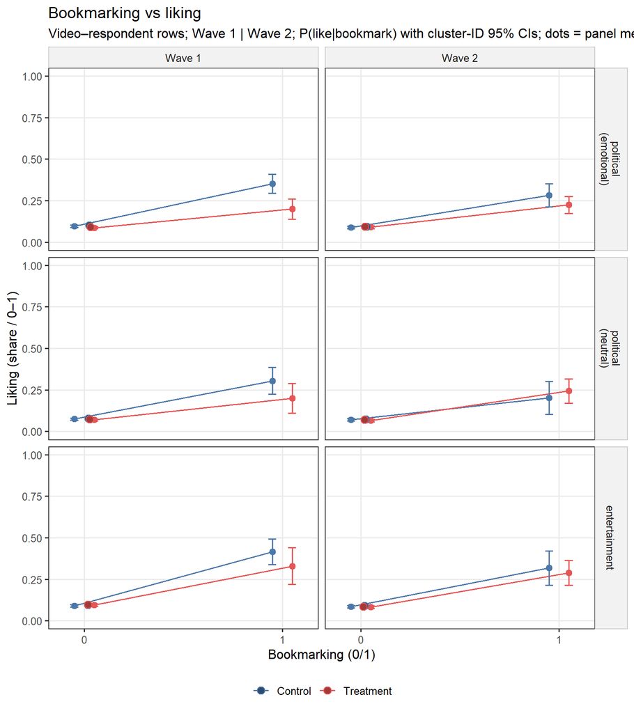

```r
fig_bookmark_like_short_long <- ggplot() +
  geom_segment(
    data = df_bookmark_like_seg,
    aes(x = x, y = y, xend = xend, yend = yend),
    color = "grey35",
    linewidth = 0.45,
    inherit.aes = FALSE
  ) +
  geom_line(
    data = df_bookmark_like_cond,
    aes(x = x_plot, y = estimate, color = treatment, group = treatment),
    linewidth = 0.55
  ) +
  geom_errorbar(
    data = df_bookmark_like_cond,
    aes(x = x_plot, ymin = conf.low, ymax = conf.high, color = treatment),
    width = 0.04,
    linewidth = 0.55
  ) +
  geom_point(
    data = df_bookmark_like_cond,
    aes(x = x_plot, y = estimate, color = treatment),
    size = 2.2
  ) +
  geom_point(
    data = df_bookmark_like_means,
    aes(x = bookmark, y = like, color = treatment, fill = treatment),
    shape = 21,
    size = 2.8,
    stroke = 0.7
  ) +
  scale_color_manual(values = treat_cols, name = NULL) +
  scale_fill_manual(values = treat_cols_dark, name = NULL) +
  scale_x_continuous(breaks = c(0, 1), limits = c(-0.12, 1.12)) +
  scale_y_continuous(limits = c(0, 1), breaks = seq(0, 1, by = 0.25)) +
  facet_grid(rows = vars(strategy), cols = vars(horizon)) +
  labs(
    title = "Bookmarking vs liking",
    subtitle = "Video–respondent rows; Wave 1 | Wave 2; P(like|bookmark) with cluster-ID 95% CIs; dots = panel means",
    x = "Bookmarking (0/1)",
    y = "Liking (share / 0–1)"
  ) +
  theme_bw(base_size = 12) +
  theme(
    panel.grid.minor = element_blank(),
    strip.background = element_rect(fill = "grey95", color = "grey80"),
    legend.position = "bottom"
  )

write_fig(
  stem = "fig_bookmark_like_short_long",
  estimates = list(
    rows = df_bookmark_like_row,
    means = df_bookmark_like_means,
    cond = df_bookmark_like_cond
  ),
  plot = fig_bookmark_like_short_long,
  width = 8,
  height = 9
)
```

# 4 Paper: secondary analyses (causal forests)

Exploratory CATE correlations. Formerly drafted as SI Section 15 / Figure S13; that SI section is commented out. # Exploratory: Causal-forest CATE correlations across outcomes

**Exploratory appendix analysis** (not a primary confirmatory claim). Motivating question: *Are those that pay attention also those that change liking and reporting behavior?* We estimate conditional average treatment effects (CATEs) separately for **Watch Time**, **Skip**, **Like**, **Report**, **Share**, and **Bookmark** using `grf::causal_forest`, then inspect how those CATEs co-vary across outcomes (attention ↔︎ engagement). The main 4×4 grid still displays **Watch Time / Skip / Like / Report**; Share and Bookmark CATEs are saved and used in companion scatters.

Fitting six causal forests is **slow**. The switch `RUN_FORESTS` in the configuration chunk controls whether forests are refit (`TRUE`) or whether the document reuses saved CATEs from `additional/ests/fig_causal_forest_cate_corr.rds` (`FALSE`, default) and only rebuilds the correlation grid / figure. Set `RUN_FORESTS <- TRUE` once after a code or data change that affects the forests, then return it to `FALSE` for ordinary compiles.

**Unit of analysis.** Each observation is a **person × sending-party** cell (`ID` × `party`): on emotionally manipulative political videos (`strategy_2 == strategies[1]` / `"political\n(emotional)"`, `wave_9`), outcomes are the mean of the video-level measures over videos from that party shown to that respondent (Watch Time = `watch_percentage_`; Skip = `skipped_video_`; Like / Report / Share / Bookmark = binary engagement indicators). A unique unit id `pp_id` identifies each person–party cell; all OOB $\hat\tau$ predictions are at this level (not person–video). Treatment $W$ is `workshop_Treatment` (constant within respondent). We try `clusters = ID` (person, higher than the unit) so multiple party-cells per person are not treated as independent; if `grf` rejects that, forests are fit **without** clustering rather than coarsening units.

**Covariates $X$.** Respondent-level covariates from `labels_en`, merged from `df_w9_w10` via `ID` / `id_w9`, **plus full sending-party dummies** for the cell’s `party` (same coding as `party_codes` / party names). Party must enter $X$ so $\hat\tau(X)$ can differ by sending party (including AfD vs non-AfD). Rows with missing $Y$, $W$, or $X$ are dropped (listwise). Covariates with very high missingness on this sample (notably structurally missing `tiktok_potential_*` for current users, and `berufliche_stellung`) are omitted from $X$ before listwise deletion so the forest sample is not restricted to non-users; omissions are reported in the chunk output when forests are fit.

**Reading the 4×4.** Off-diagonal panels scatter OOB CATE estimates for one outcome against another (each point = one person×party unit). Positive correlation means units with more positive estimated effects on one outcome also tend to have more positive effects on the other. Of particular interest for the attention question: whether Watch Time / Skip CATEs co-vary with Like / Report CATEs. Diagonal panels show the marginal distribution of each outcome’s CATE. A numeric correlation matrix is saved alongside the figure.

```r
set.seed(20260804)

# Fit all six; 4×4 display stays Watch Time / Skip / Like / Report
cf_outcomes_fit <- c("Watch Time", "Skip", "Like", "Report", "Share", "Bookmark")
cf_outcomes <- c("Watch Time", "Skip", "Like", "Report")
cf_est_path <- file.path(est_dir, "fig_causal_forest_cate_corr.rds")
if (!isTRUE(RUN_FORESTS) && !file.exists(cf_est_path)) {
  legacy_cf <- file.path("ests", "fig_causal_forest_cate_corr.rds")
  if (file.exists(legacy_cf)) cf_est_path <- legacy_cf
}

if (isTRUE(RUN_FORESTS)) {
  # --- Person × sending-party means on emotional-political wave_9 -----------
  df_cf_vid <- datasets$wave_9 |>
    filter(strategy_2 == strategies[1])

  rename_map <- setNames(unname(v_outcomes[cf_outcomes_fit]), cf_outcomes_fit)
  party_order_cf_x <- names(party_codes)

  df_cf_base <- df_cf_vid |>
    transmute(
      ID = as.character(ID),
      party = party,
      W = as.numeric(workshop_Treatment),
      across(all_of(unname(v_outcomes[cf_outcomes_fit])))
    ) |>
    rename(!!!rename_map) |>
    filter(party %in% party_order_cf_x) |>
    group_by(ID, party) |>
    summarise(
      W = first(W),
      across(all_of(cf_outcomes_fit), \(z) mean(as.numeric(z), na.rm = TRUE)),
      n_videos = n(),
      .groups = "drop"
    ) |>
    mutate(pp_id = paste(ID, party, sep = "__"))

  # Sending-party dummies for X (required so τ̂(X) can differ by party / AfD)
  for (p in party_order_cf_x) {
    col <- paste0("video_party_", gsub("[^A-Za-z0-9]+", "_", p))
    df_cf_base[[col]] <- as.integer(df_cf_base$party == p)
  }
  party_x_cols <- paste0("video_party_", gsub("[^A-Za-z0-9]+", "_", party_order_cf_x))

  # --- Merge respondent covariates from labels_en / df_w9_w10 ---------------
  x_candidates <- names(labels_en)
  x_available <- intersect(x_candidates, names(df_w9_w10))
  x_missing_from_data <- setdiff(x_candidates, names(df_w9_w10))

  df_cf_covs <- df_w9_w10 |>
    transmute(
      ID = as.character(id_w9),
      across(all_of(x_available), \(z) as.numeric(haven::zap_labels(z)))
    )

  df_cf <- df_cf_base |>
    left_join(df_cf_covs, by = "ID")

  # Drop high-missingness respondent covariates before listwise deletion
  miss_rate_x <- sapply(x_available, \(v) mean(is.na(df_cf[[v]])))
  x_high_miss <- names(miss_rate_x)[miss_rate_x > 0.25]
  x_resp_use <- setdiff(x_available, x_high_miss)
  x_use <- c(x_resp_use, party_x_cols)

  n_before <- nrow(df_cf)
  df_cf_cc <- df_cf |>
    filter(W %in% c(0, 1)) |>
    drop_na(all_of(c(cf_outcomes_fit, "W", x_use)))
  n_after <- nrow(df_cf_cc)
  n_id_after <- n_distinct(df_cf_cc$ID)

  cat(
    "Causal-forest sample (exploratory; RUN_FORESTS = TRUE)\n",
    "  Unit: person × sending party (emotional political, wave_9)\n",
    "  Outcomes fit: ", paste(cf_outcomes_fit, collapse = ", "), "\n",
    "  ID×party cells before listwise: ", n_before, "\n",
    "  ID×party cells after listwise:  ", n_after,
    "  (unique IDs: ", n_id_after, ")\n",
    "  labels_en covariates available: ", length(x_available),
    " / ", length(x_candidates), "\n",
    "  Sending-party dummies in X: ", length(party_x_cols), "\n",
    sep = ""
  )
  if (length(x_missing_from_data)) {
    cat("  Not found in df_w9_w10: ", paste(x_missing_from_data, collapse = ", "), "\n", sep = "")
  }
  if (length(x_high_miss)) {
    cat(
      "  Dropped from X (>25% missing on person×party sample):\n",
      paste0(
        "    - ", x_high_miss, " (", sprintf("%.1f%%", 100 * miss_rate_x[x_high_miss]), ")",
        collapse = "\n"
      ),
      "\n",
      sep = ""
    )
  }
  cat("  X columns used (", length(x_use), "): ", paste(x_use, collapse = ", "), "\n", sep = "")

  X_cf <- as.matrix(df_cf_cc[, x_use, drop = FALSE])
  storage.mode(X_cf) <- "double"
  W_cf <- as.numeric(df_cf_cc$W)
  clusters_person <- as.numeric(factor(df_cf_cc$ID))

  # Try person-level clustering (higher than unit); drop if grf rejects it
  cf_clusters_used <- "ID"
  clusters_arg <- clusters_person

  # --- Causal forests; OOB CATE predictions (fit one-at-a-time) -------------
  cate_mat_fit <- matrix(NA_real_, nrow = nrow(df_cf_cc), ncol = length(cf_outcomes_fit))
  colnames(cate_mat_fit) <- cf_outcomes_fit
  for (Y in cf_outcomes_fit) {
    cat("Fitting causal forest for ", Y, "...\n", sep = "")
    y_vec <- as.numeric(df_cf_cc[[Y]])
    fit <- tryCatch(
      {
        if (!is.null(clusters_arg)) {
          grf::causal_forest(X = X_cf, Y = y_vec, W = W_cf, clusters = clusters_arg)
        } else {
          grf::causal_forest(X = X_cf, Y = y_vec, W = W_cf)
        }
      },
      error = function(e) {
        if (!is.null(clusters_arg)) {
          cat(
            "  clusters = ID failed for ", Y, " (", conditionMessage(e),
            "); dropping clustering for remaining forests.\n",
            sep = ""
          )
          cf_clusters_used <<- "none"
          clusters_arg <<- NULL
          grf::causal_forest(X = X_cf, Y = y_vec, W = W_cf)
        } else {
          stop(e)
        }
      }
    )
    cate_mat_fit[, Y] <- as.numeric(predict(fit)$predictions)
    rm(fit)
  }
  if (identical(cf_clusters_used, "ID")) {
    cat("  Clustering used: clusters = ID (person; multiple party-units per cluster).\n")
  } else {
    cat("  Clustering used: none (person-level clustering dropped).\n")
  }

  df_cate <- df_cf_cc |>
    select(pp_id, ID, party, W) |>
    bind_cols(as_tibble(cate_mat_fit))

  cate_cor_fit <- cor(cate_mat_fit, use = "pairwise.complete.obs")
  cate_mat <- cate_mat_fit[, cf_outcomes, drop = FALSE]
  cate_cor <- cate_cor_fit[cf_outcomes, cf_outcomes, drop = FALSE]

  # Within-ID Like CATE variation (sanity: party in X should yield non-zero range)
  within_like <- df_cate |>
    group_by(ID) |>
    summarise(
      n_parties = n(),
      like_range = diff(range(Like, na.rm = TRUE)),
      .groups = "drop"
    )
  pct_vary <- mean(within_like$like_range > 1e-12, na.rm = TRUE)
  cat(
    "  Within-ID Like CATE: share of IDs with range > 0 = ",
    sprintf("%.1f%%", 100 * pct_vary),
    " (median range = ", sprintf("%.4f", median(within_like$like_range, na.rm = TRUE)),
    ")\n",
    sep = ""
  )

  cf_estimates <- list(
    cate_unit = df_cate,
    cate_cor = cate_cor,
    cate_cor_fit = cate_cor_fit,
    n_cells = n_after,
    n_ids = n_id_after,
    unit = "person-party",
    outcomes = cf_outcomes_fit,
    outcomes_display = cf_outcomes,
    clusters_used = cf_clusters_used,
    x_used = x_use,
    x_dropped_high_miss = x_high_miss,
    miss_rate_x = miss_rate_x,
    party_x_cols = party_x_cols,
    within_id_like_pct_vary = pct_vary,
    within_id_like_median_range = median(within_like$like_range, na.rm = TRUE)
  )

  # Persist CATEs (and metadata needed for plotting) before graphing
  write_rds(cate_cor, file.path(est_dir, "causal_forest_cate_cor.rds"))
  write_rds(cf_estimates, cf_est_path)
} else {
  if (!file.exists(cf_est_path)) {
    stop(
      "Causal-forest estimates not found at '", cf_est_path, "'. ",
      "Set RUN_FORESTS <- TRUE once in the configuration chunk to fit and save, ",
      "then set RUN_FORESTS <- FALSE for ordinary compiles.",
      call. = FALSE
    )
  }
  cat(
    "RUN_FORESTS = FALSE: loading saved CATEs from ", cf_est_path,
    " (no forest refit).\n",
    sep = ""
  )
  cf_estimates <- read_rds(cf_est_path)
  needed <- c("cate_unit", "cate_cor")
  missing_bits <- setdiff(needed, names(cf_estimates))
  if (length(missing_bits)) {
    stop(
      "Saved causal-forest artifact is incomplete (missing: ",
      paste(missing_bits, collapse = ", "),
      "). Set RUN_FORESTS <- TRUE once to refit and save.",
      call. = FALSE
    )
  }
  df_cate <- cf_estimates$cate_unit
  if (!all(cf_outcomes_fit %in% names(df_cate))) {
    stop(
      "Saved cate_unit is missing outcome columns (expected fit set: ",
      paste(cf_outcomes_fit, collapse = ", "), "). ",
      "Set RUN_FORESTS <- TRUE once to refit and save.",
      call. = FALSE
    )
  }
  if (!is.null(cf_estimates$outcomes) &&
      !all(cf_outcomes_fit %in% cf_estimates$outcomes)) {
    stop(
      "Saved outcomes (", paste(cf_estimates$outcomes, collapse = ", "),
      ") missing required fit outcomes (", paste(cf_outcomes_fit, collapse = ", "),
      "). Set RUN_FORESTS <- TRUE once to refit and save.",
      call. = FALSE
    )
  }
  if (!("party" %in% names(df_cate))) {
    stop(
      "Saved cate_unit is missing party (expected for person×party units). ",
      "Set RUN_FORESTS <- TRUE once to refit and save.",
      call. = FALSE
    )
  }
  unit_loaded <- if (!is.null(cf_estimates$unit)) cf_estimates$unit else "unknown"
  if (!identical(unit_loaded, "person-party")) {
    stop(
      "Saved artifact unit = '", unit_loaded, "' (expected person-party). ",
      "Set RUN_FORESTS <- TRUE once to refit and save.",
      call. = FALSE
    )
  }
  cate_mat <- as.matrix(df_cate[, cf_outcomes, drop = FALSE])
  if (!is.null(cf_estimates$cate_cor) &&
      all(cf_outcomes %in% rownames(cf_estimates$cate_cor)) &&
      all(cf_outcomes %in% colnames(cf_estimates$cate_cor))) {
    cate_cor <- cf_estimates$cate_cor[cf_outcomes, cf_outcomes, drop = FALSE]
  } else {
    cate_cor <- cor(cate_mat, use = "pairwise.complete.obs")
  }
  n_cells_loaded <- if (!is.null(cf_estimates$n_cells)) cf_estimates$n_cells else nrow(df_cate)
  n_ids_loaded <- if (!is.null(cf_estimates$n_ids)) {
    cf_estimates$n_ids
  } else {
    dplyr::n_distinct(df_cate$ID)
  }
  cf_clusters_used <- if (!is.null(cf_estimates$clusters_used)) {
    cf_estimates$clusters_used
  } else {
    "unknown"
  }
  cat(
    "  Loaded person×party units: ", n_cells_loaded,
    "  (unique IDs: ", n_ids_loaded, "; unit tag: ", unit_loaded,
    "; clusters: ", cf_clusters_used, ")\n",
    "  Fit outcomes present: ", paste(cf_outcomes_fit, collapse = ", "), "\n",
    "  4×4 display outcomes: ", paste(cf_outcomes, collapse = ", "), "\n",
    sep = ""
  )
}
```

```
RUN_FORESTS = FALSE: loading saved CATEs from additional/ests/fig_causal_forest_cate_corr.rds (no forest refit).
  Loaded person×party units: 17156  (unique IDs: 3580; unit tag: person-party; clusters: ID)
  Fit outcomes present: Watch Time, Skip, Like, Report, Share, Bookmark
  4×4 display outcomes: Watch Time, Skip, Like, Report
```

```r
if (!exists("cf_clusters_used")) {
  cf_clusters_used <- if (!is.null(cf_estimates$clusters_used)) {
    cf_estimates$clusters_used
  } else {
    "unknown"
  }
}
cf_cluster_lab <- if (identical(cf_clusters_used, "ID")) {
  "clusters = ID"
} else if (identical(cf_clusters_used, "none")) {
  "no clustering"
} else {
  paste0("clusters = ", cf_clusters_used)
}

cat("\nCATE correlation matrix (OOB):\n")
```

```
CATE correlation matrix (OOB):
```

```r
print(round(cate_cor, 3))
```

```
           Watch Time   Skip   Like Report
Watch Time      1.000 -0.820  0.383  0.371
Skip           -0.820  1.000 -0.334 -0.350
Like            0.383 -0.334  1.000  0.158
Report          0.371 -0.350  0.158  1.000
```

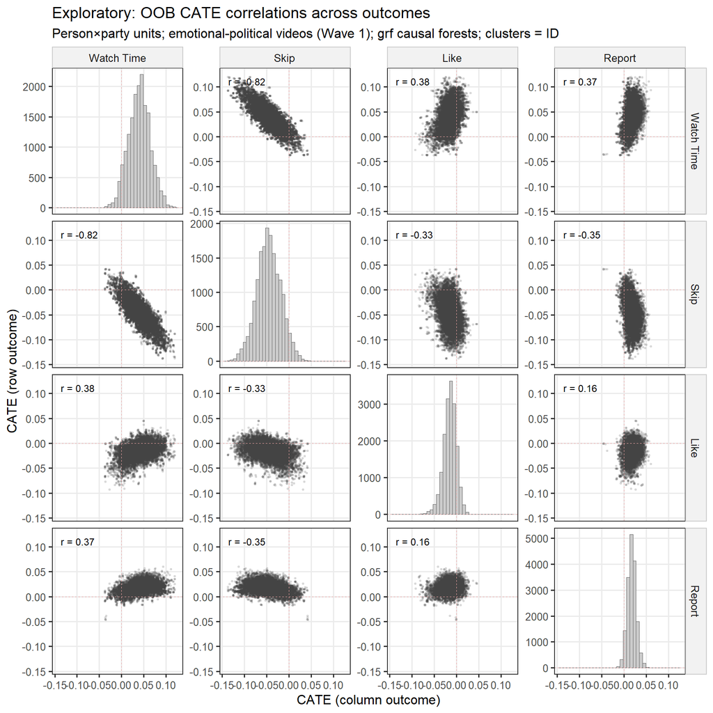

```r
# --- 4×4 scatter / correlation grid ----------------------------------------
plot_list <- vector("list", length(cf_outcomes)^2)
k <- 1L
for (vx in cf_outcomes) {
  for (vy in cf_outcomes) {
    plot_list[[k]] <- tibble(
      var_x = factor(vx, levels = cf_outcomes),
      var_y = factor(vy, levels = cf_outcomes),
      x = cate_mat[, vx],
      y = cate_mat[, vy],
      is_diag = vx == vy
    )
    k <- k + 1L
  }
}
plot_cf_long <- bind_rows(plot_list)

# Shared CATE axis limits for all x panels and off-diagonal y panels.
# Derived from fitted CATEs (Watch Time can differ in scale from binary outcomes).
# Diagonal histograms keep free count y-scales (see facetted_pos_scales below).
cate_rng <- range(cate_mat, na.rm = TRUE)
cate_pad <- 0.05 * diff(cate_rng)
if (!is.finite(cate_pad) || cate_pad <= 0) cate_pad <- 0.01
cate_lim <- c(cate_rng[1] - cate_pad, cate_rng[2] + cate_pad)

# Correlation annotations for off-diagonal panels
cor_labels <- as.data.frame(as.table(cate_cor)) |>
  as_tibble() |>
  rename(var_x = Var1, var_y = Var2, r = Freq) |>
  filter(var_x != var_y) |>
  mutate(
    var_x = factor(var_x, levels = cf_outcomes),
    var_y = factor(var_y, levels = cf_outcomes),
    label = sprintf("r = %.2f", r),
    x = cate_lim[1] + 0.05 * diff(cate_lim),
    y = cate_lim[2] - 0.05 * diff(cate_lim)
  )

# Per-panel y scales: fixed CATE limits off-diagonal; NULL = free counts on diagonal.
# Order matches facet_grid layout (row-major: var_y outer, var_x inner).
cf_y_scales <- lapply(cf_outcomes, function(vy) {
  lapply(cf_outcomes, function(vx) {
    if (identical(vx, vy)) {
      NULL
    } else {
      scale_y_continuous(
        limits = cate_lim,
        expand = expansion(mult = 0.02)
      )
    }
  })
}) |>
  unlist(recursive = FALSE)

# Soft red zero guides: hline on all panels (CATE y = 0 off-diag; count = 0 on diag);
# vline on all panels (CATE x = 0, including diagonal histograms).
cf_zero_col <- "#f4a6a6"

fig_cf_cate_corr <- ggplot() +
  geom_point(
    data = plot_cf_long |> filter(!is_diag),
    aes(x = x, y = y),
    alpha = 0.12,
    size = 0.55,
    color = "grey25"
  ) +
  geom_histogram(
    data = plot_cf_long |> filter(is_diag),
    aes(x = x),
    bins = 40,
    fill = "grey80",
    color = "grey40",
    linewidth = 0.2
  ) +
  geom_hline(
    data = plot_cf_long,
    aes(yintercept = 0),
    linewidth = 0.35,
    linetype = "dashed",
    color = cf_zero_col
  ) +
  geom_vline(
    data = plot_cf_long,
    aes(xintercept = 0),
    linewidth = 0.35,
    linetype = "dashed",
    color = cf_zero_col
  ) +
  geom_text(
    data = cor_labels,
    aes(x = x, y = y, label = label),
    hjust = 0,
    vjust = 1,
    size = 3.1
  ) +
  # Shared x across all panels (CATE). independent="y" keeps diagonal histogram
  # counts off the scatter y-axes; facetted_pos_scales then pins off-diagonal
  # y to the same CATE limits as x.
  facet_grid2(
    rows = vars(var_y),
    cols = vars(var_x),
    scales = "free_y",
    independent = "y"
  ) +
  scale_x_continuous(
    limits = cate_lim,
    expand = expansion(mult = 0.02)
  ) +
  facetted_pos_scales(y = cf_y_scales) +
  labs(
    title = "Exploratory: OOB CATE correlations across outcomes",
    subtitle = paste0(
      "Person×party units; emotional-political videos (Wave 1); grf causal forests; ",
      cf_cluster_lab
    ),
    x = "CATE (column outcome)",
    y = "CATE (row outcome)"
  ) +
  theme_bw(base_size = 12) +
  theme(
    panel.grid.minor = element_blank(),
    strip.background = element_rect(fill = "grey95", color = "grey80")
  )

write_rds(cate_cor, file.path(est_dir, "causal_forest_cate_cor.rds"))

write_fig(
  stem = "fig_causal_forest_cate_corr",
  estimates = cf_estimates,
  plot = fig_cf_cate_corr,
  width = 9,
  height = 9
)
```

**Bookmark vs Report CATEs (OOB).** Same person×party units and forest fits as the 4×4; scatter of **Bookmark** CATE (x) against **Report** CATE (y). Soft-red zero guides match the correlation grid. Reuses saved CATEs when `RUN_FORESTS <- FALSE`.

```r
n_br <- nrow(df_cate)
r_br <- cor(df_cate$Bookmark, df_cate$Report, use = "pairwise.complete.obs")
cat(
  "Bookmark vs Report OOB CATE scatter (exploratory)\n",
  "  Person×party units: ", n_br,
  "  (unique IDs: ", dplyr::n_distinct(df_cate$ID), ")\n",
  "  cor(Bookmark, Report) = ", sprintf("%.3f", r_br), "\n",
  sep = ""
)
```

```
Bookmark vs Report OOB CATE scatter (exploratory)
  Person×party units: 17156  (unique IDs: 3580)
  cor(Bookmark, Report) = 0.228
```

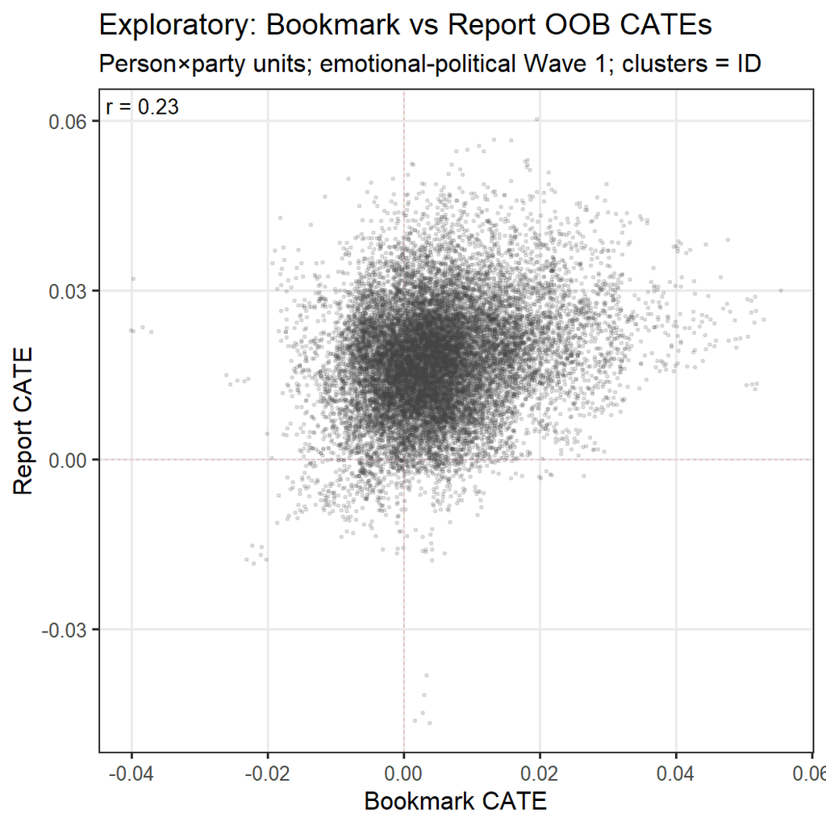

```r
cf_zero_col_br <- "#f4a6a6"
fig_cf_bookmark_report <- ggplot(
  df_cate,
  aes(x = Bookmark, y = Report)
) +
  geom_hline(
    yintercept = 0,
    linewidth = 0.35,
    linetype = "dashed",
    color = cf_zero_col_br
  ) +
  geom_vline(
    xintercept = 0,
    linewidth = 0.35,
    linetype = "dashed",
    color = cf_zero_col_br
  ) +
  geom_point(alpha = 0.12, size = 0.55, color = "grey25") +
  annotate(
    "text",
    x = -Inf,
    y = Inf,
    label = sprintf("r = %.2f", r_br),
    hjust = -0.1,
    vjust = 1.5,
    size = 3.5
  ) +
  labs(
    title = "Exploratory: Bookmark vs Report OOB CATEs",
    subtitle = paste0(
      "Person×party units; emotional-political Wave 1; ",
      cf_cluster_lab
    ),
    x = "Bookmark CATE",
    y = "Report CATE"
  ) +
  theme_bw(base_size = 12) +
  theme(
    panel.grid.minor = element_blank()
  )

write_fig(
  stem = "fig_causal_forest_bookmark_report",
  estimates = df_cate |> select(pp_id, ID, party, W, Bookmark, Report),
  plot = fig_cf_bookmark_report,
  width = 5.5,
  height = 5.5
)
```

**Watch Time vs Like CATEs by AfD vs not AfD (viewer × video).** Same OOB forest CATEs as the 4×4 grid (**Watch Time** and **Like** columns of `cate_unit`) — companion scatter for the attention↔︎liking question. Exclusive wave-9 party ID (`party_id_w9_*` on `df_w9_w10`) and cell `party` (sending party) are each collapsed to binary **AfD** vs **Not AfD**. Facet order is `AfD`, `Not AfD` on both axes so the **diagonal** is same/same (AfD viewer + AfD sender; not-AfD viewer + not-AfD sender). Respondents with Other/None/missing party ID are dropped from this figure only. Reuses saved CATEs when `RUN_FORESTS <- FALSE` (no forest refit). Because units are person×party and sending party is in $X$, CATEs can differ by party within the same respondent.

```r
# Binary AfD vs Not AfD (order keeps same/same on the diagonal)
afd_facet_levels <- c("AfD", "Not AfD")
party_order_cf <- names(party_codes)

# Viewer party: exclusive wave-9 party ID, then collapse to AfD vs Not AfD
viewer_party_lookup <- {
  stubs <- unname(party_codes[party_order_cf])
  party_mat <- sapply(stubs, function(stub) {
    as.integer(df_w9_w10[[paste0("party_id_w9_", stub)]] == 1)
  })
  viewer <- rep(NA_character_, nrow(df_w9_w10))
  for (j in seq_along(stubs)) {
    hit <- which(party_mat[, j] == 1L)
    viewer[hit] <- party_order_cf[j]
  }
  tibble(
    ID = as.character(df_w9_w10$id_w9),
    party_viewer_full = viewer
  ) |>
    distinct(ID, .keep_all = TRUE)
}

df_cate_wl <- df_cate |>
  mutate(ID = as.character(ID)) |>
  left_join(viewer_party_lookup, by = "ID") |>
  filter(
    !is.na(party_viewer_full),
    party_viewer_full %in% party_order_cf,
    party %in% party_order_cf
  ) |>
  mutate(
    party_viewer = factor(
      ifelse(party_viewer_full == "AfD", "AfD", "Not AfD"),
      levels = afd_facet_levels
    ),
    party_video = factor(
      ifelse(party == "AfD", "AfD", "Not AfD"),
      levels = afd_facet_levels
    )
  )

cat(
  "Watch Time vs Like CATE by AfD vs Not AfD (exploratory)\n",
  "  Person×party units with known viewer party: ", nrow(df_cate_wl),
  "  (unique IDs: ", dplyr::n_distinct(df_cate_wl$ID), ")\n",
  "  Facet rows = viewer AfD/Not AfD; cols = sender AfD/Not AfD; ",
  "diagonal = same/same.\n",
  sep = ""
)
```

```
Watch Time vs Like CATE by AfD vs Not AfD (exploratory)
  Person×party units with known viewer party: 13638  (unique IDs: 2882)
  Facet rows = viewer AfD/Not AfD; cols = sender AfD/Not AfD; diagonal = same/same.
```

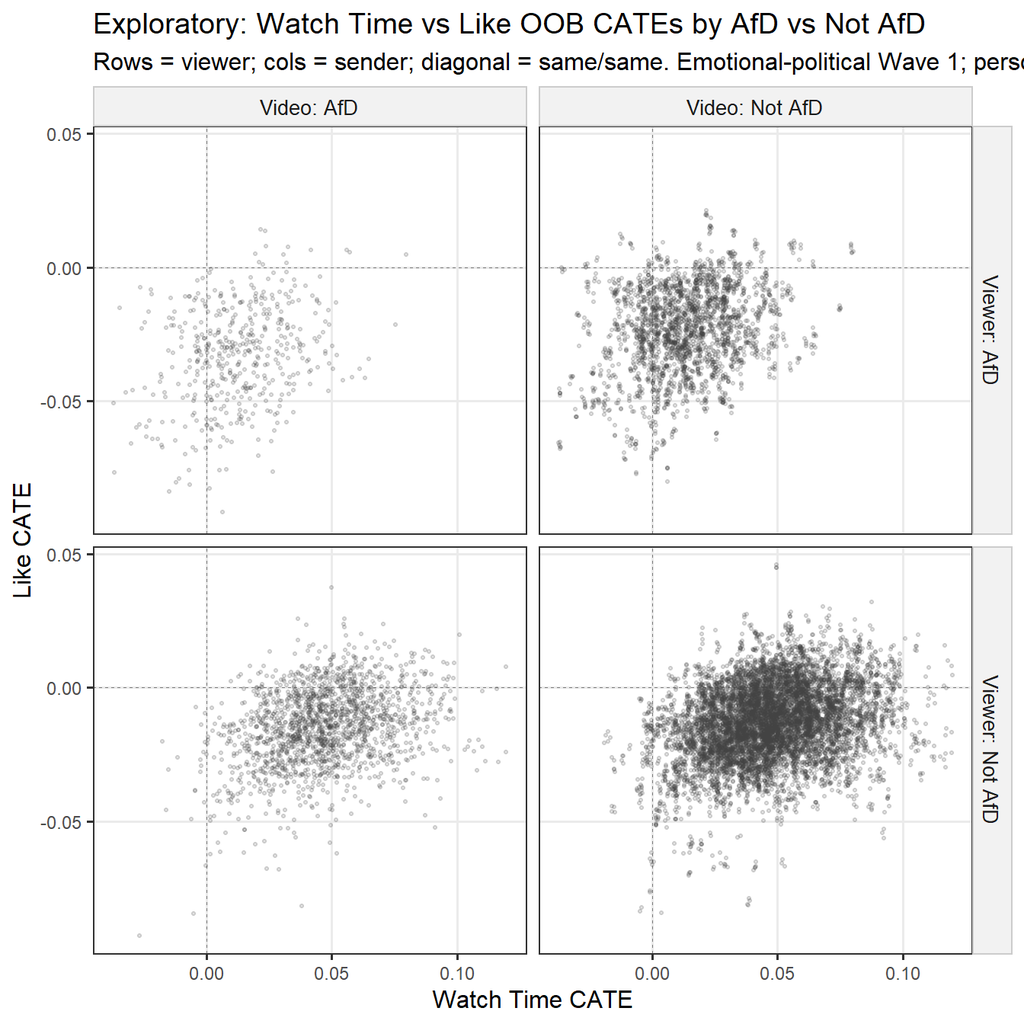

```r
fig_cf_watch_like_by_party <- ggplot(
  df_cate_wl,
  aes(x = `Watch Time`, y = Like)
) +
  geom_hline(yintercept = 0, linewidth = 0.3, linetype = "dashed", color = "grey50") +
  geom_vline(xintercept = 0, linewidth = 0.3, linetype = "dashed", color = "grey50") +
  geom_point(alpha = 0.15, size = 0.7, color = "grey25") +
  facet_grid(
    rows = vars(party_viewer),
    cols = vars(party_video),
    labeller = labeller(
      party_viewer = function(x) paste0("Viewer: ", x),
      party_video = function(x) paste0("Video: ", x)
    )
  ) +
  labs(
    title = "Exploratory: Watch Time vs Like OOB CATEs by AfD vs Not AfD",
    subtitle = "Rows = viewer; cols = sender; diagonal = same/same. Emotional-political Wave 1; person×party units",
    x = "Watch Time CATE",
    y = "Like CATE"
  ) +
  theme_bw(base_size = 12) +
  theme(
    panel.grid.minor = element_blank(),
    strip.background = element_rect(fill = "grey95", color = "grey80"),
    strip.text = element_text(size = 10),
    axis.text = element_text(size = 9)
  )

write_fig(
  stem = "fig_causal_forest_watch_like_by_party",
  estimates = df_cate_wl,
  plot = fig_cf_watch_like_by_party,
  width = 7,
  height = 7
)
```

# 5 SI: ecological validity of the intervention

Comment classification by treatment (Wave 1), not shown in SI Figure S2. **Wave 1 by treatment.** Same classification shares, restricted to respondents who appear in `df_w9_w10` (wave-9 id + workshop arm). Facets = Control | Treatment. Shares renormalize within each panel. Video-type facets are **not** available here: open-ended comments are one per respondent after a mixed feed (almost everyone sees emotional, neutral, and entertainment), not video-row text.

```r
levels_vec <- c(
  "0 = setup skepticism",
  "1 = platform-focused",
  "2 = content-focused",
  "3 = other/unclear"
)

comments_w9_treat <- comments_df |>
  mutate(ID = as.character(ID_W9)) |>
  inner_join(
    df_w9_w10 |>
      transmute(
        ID = as.character(id_w9),
        treatment = factor(
          ifelse(workshop == 1, "Treatment", "Control"),
          levels = c("Control", "Treatment")
        )
      ) |>
      distinct(ID, .keep_all = TRUE),
    by = "ID"
  ) |>
  mutate(
    scale_label = fct_explicit_na(scale_label, na_level = "NA"),
    scale_label = fct_relevel(scale_label, levels_vec, after = 0)
  )

comments_w9_treat_counts <- comments_w9_treat |>
  count(treatment, scale_label, name = "n") |>
  group_by(treatment) |>
  mutate(pct = n / sum(n)) |>
  ungroup()

cat(
  "Comment classification by treatment (wave-9 ids in df_w9_w10)\n",
  "  N comments: ", nrow(comments_w9_treat),
  " (Control=", sum(comments_w9_treat$treatment == "Control"),
  "; Treatment=", sum(comments_w9_treat$treatment == "Treatment"), ")\n",
  sep = ""
)
```

```
Comment classification by treatment (wave-9 ids in df_w9_w10)
  N comments: 2140 (Control=1099; Treatment=1041)
```

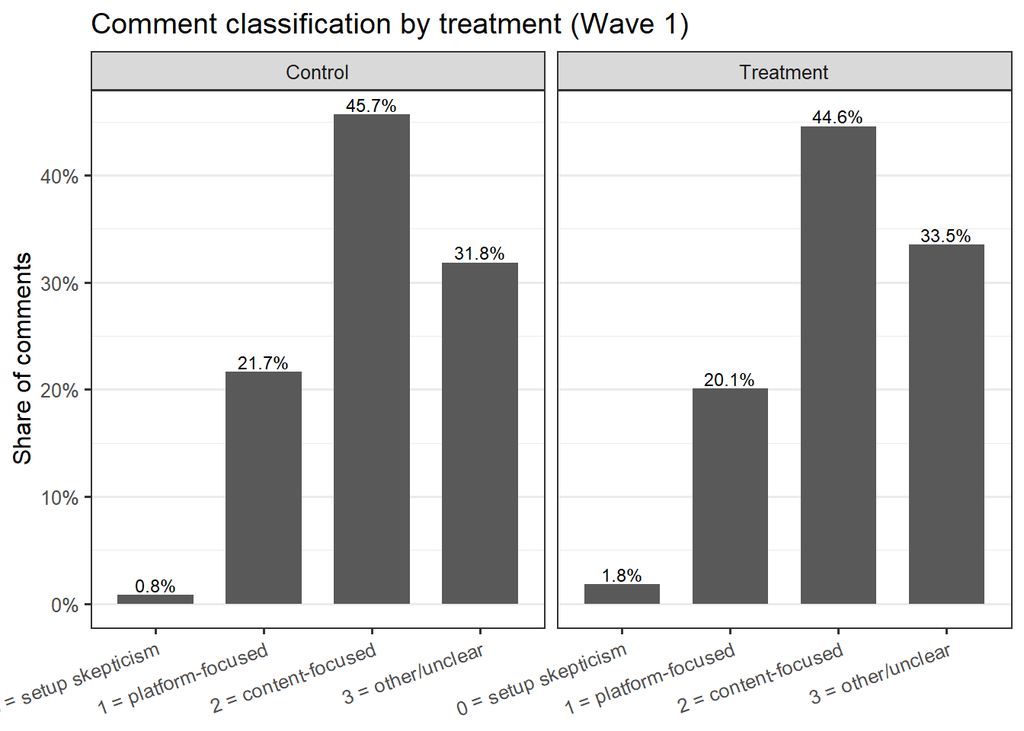

```r
comments_plot_w9_treat <- ggplot(
  comments_w9_treat_counts,
  aes(x = scale_label, y = pct)
) +
  geom_col(width = 0.7) +
  geom_text(aes(label = percent(pct, accuracy = 0.1)),
            vjust = -0.25, size = 3.2) +
  facet_wrap(~treatment, nrow = 1) +
  scale_y_continuous(labels = percent_format(accuracy = 1)) +
  labs(
    x = NULL, y = "Share of comments",
    title = "Comment classification by treatment (Wave 1)"
  ) +
  theme_bw(base_size = 12) +
  theme(
    panel.grid.major.x = element_blank(),
    axis.text.x = element_text(angle = 20, hjust = 1)
  )

write_fig(
  stem = "fig_classification_comments_w9_by_treatment",
  estimates = comments_w9_treat_counts,
  plot = comments_plot_w9_treat,
  width = 10,
  height = 4.5
)
```

# 6 SI: AfD-specific effects

Treatment x AfD-supporter models stratified by AfD vs other senders (distinct from SI Tables S10-S11). ## Treatment effects by AfD video

Heterogeneity of Wave 1 treatment effects by respondent AfD supporter status, with columns 2–3 stratified by whether the video’s sending party is AfD. **Sample restriction:** emotionally manipulative political videos only — `strategy_2 == strategies[1]` i.e. `"political\n(emotional)"` in `wave_9` (not all political content; not entertainment). Same content type as the main emotional-political estimates. AfD supporter status is `AFD = 1{party_preference_afd == 1}` (respondent). AfD-video stratification uses `afd_video = 1{party == "AfD"}` (sending party).

In every column we estimate the same interaction

$$Y = \beta_1 \text{Treatment} + \beta_2 \text{AFD} + \beta_3 (\text{Treatment} \times \text{AFD}) + \alpha_{\text{video}} + \varepsilon$$

with **video FE** and SEs clustered by respondent. Columns: (1) all political-emotional videos; (2) AfD videos only; (3) non-AfD sender videos only. Outcomes: Like and Report. $\beta_3$ is the difference in ATEs (AfD supporters minus non-supporters) within that sample. (`treatment × afd_video` is unidentified in columns 2–3 because `afd_video` is constant within those subsets.)

```r
compare_outcomes <- c("Like", "Report")

df_afd_het <- datasets$wave_9 |>
  filter(strategy_2 == strategies[1]) |>
  mutate(
    AFD = as.integer(party_preference_afd == 1),
    afd_video = as.integer(party == "AfD")
  )

afd_hetero_coef_map <- list(
  "workshop_Treatment" = "Treatment",
  "AFD" = "AfD supporter",
  "workshop_Treatment:AFD" = "Treatment × AfD supporter"
)

afd_hetero_model_names <- c(
  "All (interaction)",
  "AfD videos",
  "Other senders"
)

fit_afd_hetero <- function(df, outcome_name) {
  y <- v_outcomes[[outcome_name]]
  fml <- as.formula(paste0(y, " ~ workshop_Treatment * AFD | video"))
  list(
    `All (interaction)` = feols(fml, data = df, cluster = ~ID),
    `AfD videos` = feols(
      fml,
      data = df |> filter(afd_video == 1),
      cluster = ~ID
    ),
    `Other senders` = feols(
      fml,
      data = df |> filter(afd_video == 0),
      cluster = ~ID
    )
  )
}

# Persist tidy/glance only; full fixest lists are tens of MB.
tidy_fixest_tree <- function(x) {
  if (inherits(x, "fixest")) {
    list(tidy = broom::tidy(x, conf.int = TRUE), glance = broom::glance(x))
  } else if (is.list(x)) {
    lapply(x, tidy_fixest_tree)
  } else {
    x
  }
}

write_est_rds <- function(object, path) {
  tmp <- file.path(dirname(path), paste0(".", basename(path), ".tmp"))
  write_rds(object, tmp)
  replace_file(tmp, path)
}

write_afd_hetero_table <- function(models, outcome_name, caption, label) {
  stem <- paste0("tab_afd_video_hetero_", tolower(outcome_name))
  write_est_rds(tidy_fixest_tree(models), file.path(est_dir, paste0(stem, ".rds")))
  texreg::texreg(
    models,
    file = file.path(tab_dir, paste0(stem, ".tex")),
    digits = 3,
    include.ci = FALSE,
    custom.model.names = afd_hetero_model_names,
    custom.coef.map = afd_hetero_coef_map,
    caption = caption,
    label = label,
    stars = texreg_stars
  )
  texreg::htmlreg(
    models,
    digits = 3,
    include.ci = FALSE,
    custom.model.names = afd_hetero_model_names,
    custom.coef.map = afd_hetero_coef_map,
    caption = caption,
    stars = texreg_stars
  )
}

models_afd_het <- lapply(compare_outcomes, function(Y) {
  fit_afd_hetero(df_afd_het, Y)
}) |>
  setNames(compare_outcomes)

write_est_rds(
  tidy_fixest_tree(models_afd_het),
  file.path(est_dir, "tab_afd_video_hetero.rds")
)

cat("\n### Like\n\n")
```

### 6.0.1 Like

```r
write_afd_hetero_table(
  models_afd_het$Like,
  "Like",
  caption = "Treatment × AfD supporter, stratified by AfD video: Like (emotional political videos, Wave 1). Cols: All / AfD videos / other senders. Video FE; SEs clustered by respondent.",
  label = "tab:afd_video_hetero_like"
)
```

```
The table was written to the file 'additional/tabs/tab_afd_video_hetero_like.tex'.
```

Treatment × AfD supporter, stratified by AfD video: Like (emotional political videos, Wave 1). Cols: All / AfD videos / other senders. Video FE; SEs clustered by respondent.

|  | All (interaction) | AfD videos | Other senders |
| --- | --- | --- | --- |
| Treatment | -0.010* | -0.015** | -0.008 |
|  | (0.006) | (0.007) | (0.006) |
| AfD supporter | 0.009 | 0.188*** | -0.029*** |
|  | (0.008) | (0.018) | (0.008) |
| Treatment × AfD supporter | -0.007 | -0.044* | 0.001 |
|  | (0.011) | (0.024) | (0.011) |
| Num. obs. | 51990 | 8996 | 42994 |
| Num. groups: video | 156 | 27 | 129 |
| R<sup>2</sup> (full model) | 0.021 | 0.082 | 0.025 |
| R<sup>2</sup> (proj model) | 0.001 | 0.072 | 0.002 |
| Adj. R<sup>2</sup> (full model) | 0.018 | 0.079 | 0.022 |
| Adj. R<sup>2</sup> (proj model) | 0.000 | 0.071 | 0.002 |

***p < 0.01; **p < 0.05; *p < 0.1

```r
cat("\n### Report\n\n")
```

### 6.0.2 Report

```r
write_afd_hetero_table(
  models_afd_het$Report,
  "Report",
  caption = "Treatment × AfD supporter, stratified by AfD video: Report (emotional political videos, Wave 1). Cols: All / AfD videos / other senders. Video FE; SEs clustered by respondent.",
  label = "tab:afd_video_hetero_report"
)
```

```
The table was written to the file 'additional/tabs/tab_afd_video_hetero_report.tex'.
```

Treatment × AfD supporter, stratified by AfD video: Report (emotional political videos, Wave 1). Cols: All / AfD videos / other senders. Video FE; SEs clustered by respondent.

|  | All (interaction) | AfD videos | Other senders |
| --- | --- | --- | --- |
| Treatment | 0.018*** | 0.028*** | 0.016*** |
|  | (0.004) | (0.008) | (0.003) |
| AfD supporter | 0.004 | -0.032*** | 0.012*** |
|  | (0.004) | (0.006) | (0.004) |
| Treatment × AfD supporter | -0.015*** | -0.015 | -0.015** |
|  | (0.006) | (0.010) | (0.006) |
| Num. obs. | 51990 | 8996 | 42994 |
| Num. groups: video | 156 | 27 | 129 |
| R<sup>2</sup> (full model) | 0.011 | 0.017 | 0.007 |
| R<sup>2</sup> (proj model) | 0.002 | 0.011 | 0.003 |
| Adj. R<sup>2</sup> (full model) | 0.008 | 0.014 | 0.004 |
| Adj. R<sup>2</sup> (proj model) | 0.002 | 0.011 | 0.002 |

***p < 0.01; **p < 0.05; *p < 0.1

# 7 SI: relations between outcomes

## 7.1 fig_s15_outcome_ellipses

Within-wave pairwise outcome correlations on emotionally manipulative political videos (`strategy_2 == strategies[1]`, same content-type restriction as SI Table S14), treatment vs control, Wave 1 (`wave_9`) and Wave 2 (`wave_10`). Ellipse / numeric layout as previously in the SI analysis file. Nested Engagement / Attention strips group the first four vs last two outcomes on both axes. Stem kept; not in the compiled SI.

```r
build_cor_df <- function(df, wave_label) {
  bind_rows(lapply(c("Treated", "Control"), function(tr) {
    df_sel <- df |>
      filter(workshop_Treatment == if (tr == "Treated") 1 else 0) |>
      select(all_of(v_outcomes))
    colnames(df_sel) <- names(v_outcomes)
    as.data.frame(as.table(cor(df_sel, use = "pairwise.complete.obs"))) |>
      rename(var1 = Var1, var2 = Var2, r = Freq) |>
      mutate(treat = tr, wave = wave_label)
  }))
}

cor_long <- bind_rows(
  build_cor_df(datasets$wave_9 |> filter(strategy_2 == strategies[1]), "Wave 1"),
  build_cor_df(datasets$wave_10 |> filter(strategy_2 == strategies[1]), "Wave 2")
) |>
  mutate(sign = ifelse(r >= 0, "positive", "negative"))
var_levels <- names(v_outcomes)
cor_long <- cor_long |>
  mutate(
    x_idx = match(var2, var_levels),
    y_idx = match(var1, var_levels)
  )
scale_in_cell <- 0.42
ellipse_upper <- cor_long |>
  filter(y_idx < x_idx) |>
  group_by(wave, treat, var1, var2, r, x_idx, y_idx, sign) |>
  do({
    rr <- .$r[1]
    S <- matrix(c(1, rr, rr, 1), nrow = 2)
    e <- as.data.frame(ellipse::ellipse(S, centre = c(0, 0), level = 0.68, npoints = 80))
    maxabs <- max(max(abs(e$x)), max(abs(e$y)), 1e-9)
    e$x <- (e$x / maxabs) * scale_in_cell + .$x_idx[1]
    e$y <- (e$y / maxabs) * scale_in_cell + .$y_idx[1]
    e$wave <- .$wave[1]
    e$treat <- .$treat[1]
    e$var1 <- .$var1[1]
    e$var2 <- .$var2[1]
    e$sign <- .$sign[1]
    e$r <- rr
    e
  }) |>
  ungroup()
label_lower <- cor_long |>
  filter(y_idx > x_idx) |>
  mutate(label = sprintf("%.2f", r))
```

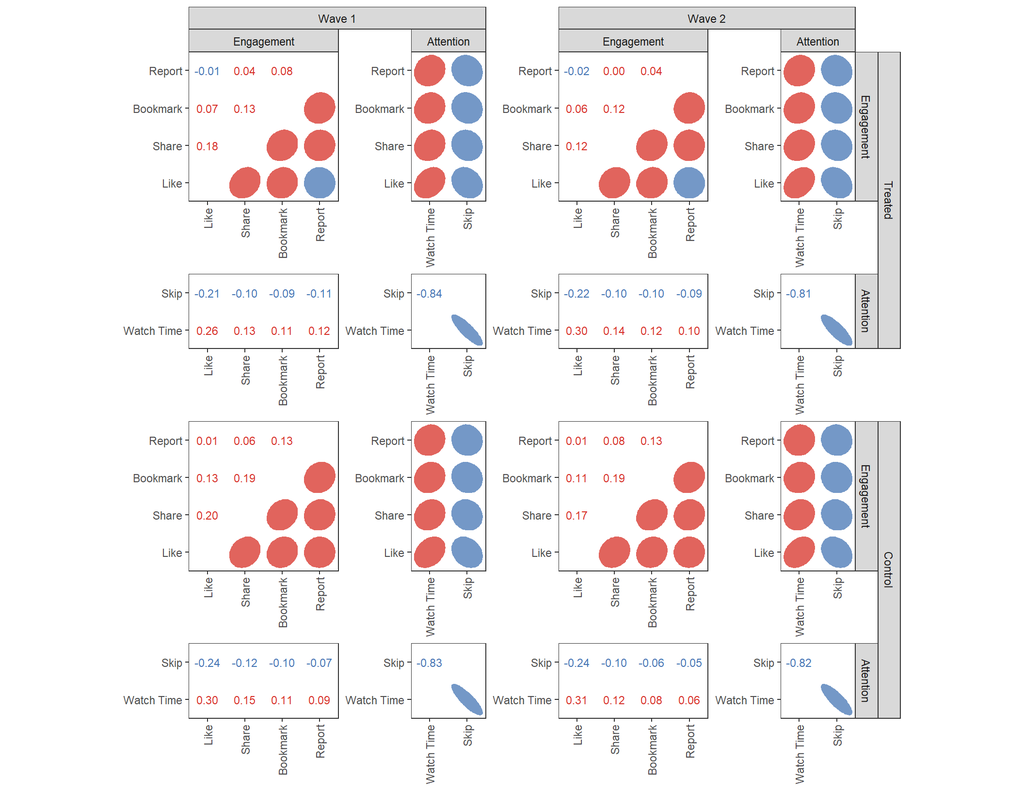

Figure 1

```r
resp_idx <- which(var_levels %in% l_outcomegroups$main)
attn_idx <- which(var_levels %in% l_outcomegroups[["_other"]])
add_outcome_supers <- function(df) {
  df |>
    mutate(
      treat = factor(treat, levels = c("Treated", "Control")),
      wave = factor(wave, levels = horizon_wave_levels),
      x_super = factor(
        if_else(as.character(var2) %in% l_outcomegroups$main, "Engagement", "Attention"),
        levels = c("Engagement", "Attention")
      ),
      y_super = factor(
        if_else(as.character(var1) %in% l_outcomegroups$main, "Engagement", "Attention"),
        levels = c("Engagement", "Attention")
      )
    )
}
ellipse_upper_plot <- add_outcome_supers(ellipse_upper)
label_lower_plot <- add_outcome_supers(label_lower)

fig_s15 <- ggplot() +
  geom_polygon(
    data = ellipse_upper_plot,
    aes(x = x, y = y, group = interaction(wave, treat, var1, var2), fill = sign),
    color = NA, alpha = 0.75
  ) +
  geom_text(
    data = label_lower_plot,
    aes(x = x_idx, y = y_idx, label = label, color = sign),
    size = 3
  ) +
  scale_fill_manual(values = c(positive = "#d73027", negative = "#4575b4"), name = "Sign") +
  scale_color_manual(values = c(positive = "#d73027", negative = "#4575b4"), guide = "none") +
  scale_x_continuous(
    breaks = seq_along(var_levels),
    labels = var_levels,
    expand = expansion(add = 0)
  ) +
  scale_y_continuous(
    breaks = seq_along(var_levels),
    labels = var_levels,
    expand = expansion(add = 0)
  ) +
  labs(x = NULL, y = NULL) +
  theme_bw() +
  theme(
    legend.position = "none",
    panel.grid = element_blank(),
    axis.text.x = element_text(angle = 90, vjust = 0.5, hjust = 1)
  ) +
  facet_nested(
    treat + y_super ~ wave + x_super,
    scales = "free",
    independent = "all"
  ) +
  scale_x_facet(
    x_super == "Engagement",
    limits = range(resp_idx) + c(-0.5, 0.5),
    breaks = resp_idx,
    labels = var_levels[resp_idx],
    expand = expansion(add = 0)
  ) +
  scale_x_facet(
    x_super == "Attention",
    limits = range(attn_idx) + c(-0.5, 0.5),
    breaks = attn_idx,
    labels = var_levels[attn_idx],
    expand = expansion(add = 0)
  ) +
  scale_y_facet(
    y_super == "Engagement",
    limits = range(resp_idx) + c(-0.5, 0.5),
    breaks = resp_idx,
    labels = var_levels[resp_idx],
    expand = expansion(add = 0)
  ) +
  scale_y_facet(
    y_super == "Attention",
    limits = range(attn_idx) + c(-0.5, 0.5),
    breaks = attn_idx,
    labels = var_levels[attn_idx],
    expand = expansion(add = 0)
  ) +
  force_panelsizes(cols = c(4, 2), rows = c(4, 2), respect = TRUE)

write_fig(
  stem = "fig_s15_outcome_ellipses",
  estimates = cor_long,
  plot = fig_s15,
  width = 11,
  height = 8.5
)
```

Companion correlation tables (Wave 2; within-arm Wave 1 vs Wave 2; person-average cross-wave) not included in compiled SI Table S14. **Outcome–outcome correlations (companion tables).** Descriptive pairwise correlations among the six engagement / attention outcomes — Like (`videoLikep1r`), Share (`videoSharep1r`), Bookmark (`videoBookmarkp1r`), Report (`videoCommentTickedp1r`), Watch time (`watch_percentage_`), Skip (`skipped_video_`) — on **emotionally manipulative political** videos only (`strategy_2 == strategies[1]`). Row-level tables use **video–respondent** rows (same unit as the watch/bookmark association figures above). Each off-diagonal cell stacks three numbers: the correlation in group A, the correlation in group B, and the difference $\Delta = r_A - r_B$, with stars on $\Delta$. Diagonals are blank (same-wave self-correlations) except Table 3. Correlations use pairwise-complete observations.

**Clustered interaction test (stars `*/**/***`).** For each outcome pair, restrict to pairwise-complete rows in the estimation subsample for that contrast; standardize both outcomes in that subsample; then estimate `feols(Y_i ~ Y_j × group, cluster = ~ID)` where `group` is treatment (Tables 1, 1b, and 3) or wave (Tables 2a/2b). With both sides standardized, the slope approximates the correlation and the **interaction** is the group difference in slopes ($\approx\Delta$). Stars mark the interaction $p$: $^{***}p<0.01$; $^{**}p<0.05$; $^{*}p<0.10$. Table 3 has one row per ID already (clustering is redundant) but uses the same interaction test for consistency.

**Tables.** (1) Row-level, Wave 1 (`wave_9`) emotional rows only: $r_T$, $r_C$, $\Delta$ with clustered-interaction stars. (1b) Same contrast on Wave 2 (`wave_10`) emotional rows only. (2a)/(2b) Row-level within treatment / control: $r_{\mathrm{Wave\ 1}}$, $r_{\mathrm{Wave\ 2}}$, $\Delta$ with the same stars. (3) Person-level: within each respondent, average each outcome over emotional-political videos in Wave 1 and in Wave 2; 6×6 with **rows = Wave 1 outcomes**, **columns = Wave 2 outcomes**; cells stack $r_T$, $r_C$, $\Delta$ with the same stars. Table 3 **includes** the diagonal (same outcome across waves).

```r
oc_labs <- c("Like", "Share", "Bookmark", "Report", "Watch time", "Skip")
oc_vars <- c(
  Like = "videoLikep1r",
  Share = "videoSharep1r",
  Bookmark = "videoBookmarkp1r",
  Report = "videoCommentTickedp1r",
  `Watch time` = "watch_percentage_",
  Skip = "skipped_video_"
)
stopifnot(identical(unname(oc_vars), unname(v_outcomes[c(
  "Like", "Share", "Bookmark", "Report", "Watch Time", "Skip"
)])))

star_p <- function(p) {
  if (!is.finite(p)) return("")
  if (p < 0.01) return("***")
  if (p < 0.05) return("**")
  if (p < 0.10) return("*")
  ""
}

fmt_r <- function(x) {
  if (!is.finite(x)) return("---")
  sprintf("%0.2f", x)
}

# Pairwise r and n (complete cases on the pair)
pair_cor <- function(x, y) {
  ok <- is.finite(x) & is.finite(y)
  n <- sum(ok)
  if (n < 3) return(list(r = NA_real_, n = n))
  list(r = suppressWarnings(cor(x[ok], y[ok])), n = n)
}

# Clustered interaction p: std(Y_i) ~ std(Y_j) * mod, cluster ID
# mod = 1 for group A, 0 for group B so interaction ≈ r_A - r_B
cluster_cor_diff_p <- function(yi, yj, mod, id) {
  ok <- is.finite(yi) & is.finite(yj) & is.finite(mod) & !is.na(id)
  if (sum(ok) < 8L) return(NA_real_)
  mod_ok <- as.numeric(mod[ok])
  if (length(unique(mod_ok)) < 2L) return(NA_real_)
  yi_ok <- as.numeric(yi[ok])
  yj_ok <- as.numeric(yj[ok])
  s_i <- stats::sd(yi_ok)
  s_j <- stats::sd(yj_ok)
  if (!is.finite(s_i) || !is.finite(s_j) || s_i <= 0 || s_j <= 0) {
    return(NA_real_)
  }
  d <- data.frame(
    yi_z = as.numeric(scale(yi_ok)),
    yj_z = as.numeric(scale(yj_ok)),
    mod = mod_ok,
    ID = as.character(id[ok]),
    stringsAsFactors = FALSE
  )
  fit <- tryCatch(
    feols(yi_z ~ yj_z * mod, data = d, cluster = ~ID),
    error = function(e) NULL
  )
  if (is.null(fit)) return(NA_real_)
  td <- broom::tidy(fit)
  hit <- td$term[grepl(":", td$term, fixed = TRUE)]
  if (length(hit) != 1L) return(NA_real_)
  as.numeric(td$p.value[td$term == hit])
}

fmt_delta_cell <- function(delta, p) {
  paste0(fmt_r(delta), star_p(p))
}

oc_num <- function(x) {
  if (inherits(x, "haven_labelled")) x <- haven::zap_labels(x)
  as.numeric(x)
}

prep_oc_rows <- function(dat, wave_lab) {
  dat |>
    filter(strategy_2 == strategies[1]) |>
    transmute(
      ID = as.character(ID),
      treatment = as.integer(workshop_Treatment),
      wave = wave_lab,
      across(all_of(unname(oc_vars)), oc_num)
    ) |>
    rename(!!!setNames(unname(oc_vars), oc_labs))
}

df_oc_row <- bind_rows(
  prep_oc_rows(datasets$wave_9, "w9"),
  prep_oc_rows(datasets$wave_10, "w10")
)

# Person averages over emotional-political videos within wave
df_oc_person <- df_oc_row |>
  group_by(ID, treatment, wave) |>
  summarise(across(all_of(oc_labs), \(z) mean(z, na.rm = TRUE)), .groups = "drop")

df_oc_person_w <- df_oc_person |>
  pivot_wider(
    id_cols = c(ID, treatment),
    names_from = wave,
    values_from = all_of(oc_labs),
    names_sep = "__"
  )

# Build long cell records for a contrast of two groups on the same outcome set
# dat: rows with ID, mod_var (1 = group A, 0 = group B), and outcome columns
# blank_diag: TRUE for same-wave 6×6; FALSE for cross-wave Table 3
build_oc_cor_cells <- function(dat, labs_row, labs_col, mod_var,
                               blank_diag = TRUE,
                               label_a = "A", label_b = "B") {
  stopifnot(mod_var %in% names(dat), "ID" %in% names(dat))
  dat_a <- dat[dat[[mod_var]] == 1, , drop = FALSE]
  dat_b <- dat[dat[[mod_var]] == 0, , drop = FALSE]
  out <- vector("list", length(labs_row) * length(labs_col))
  k <- 0L
  for (i in seq_along(labs_row)) {
    for (j in seq_along(labs_col)) {
      k <- k + 1L
      rn <- labs_row[i]
      cn <- labs_col[j]
      if (isTRUE(blank_diag) && identical(rn, cn)) {
        out[[k]] <- tibble(
          row = rn, col = cn,
          r_a = NA_real_, r_b = NA_real_, delta = NA_real_,
          n_a = NA_integer_, n_b = NA_integer_,
          p = NA_real_,
          cell = "", blank = TRUE
        )
        next
      }
      pa <- pair_cor(dat_a[[rn]], dat_a[[cn]])
      pb <- pair_cor(dat_b[[rn]], dat_b[[cn]])
      delta <- pa$r - pb$r
      p <- cluster_cor_diff_p(
        dat[[rn]], dat[[cn]], dat[[mod_var]], dat$ID
      )
      cell <- paste(
        fmt_r(pa$r),
        fmt_r(pb$r),
        fmt_delta_cell(delta, p),
        sep = "\n"
      )
      out[[k]] <- tibble(
        row = rn, col = cn,
        r_a = pa$r, r_b = pb$r, delta = delta,
        n_a = as.integer(pa$n), n_b = as.integer(pb$n),
        p = p,
        cell = cell, blank = FALSE
      )
    }
  }
  bind_rows(out) |>
    mutate(
      row = factor(row, levels = labs_row),
      col = factor(col, levels = labs_col),
      label_a = label_a,
      label_b = label_b
    )
}

# Cross-wave person table: rows = w9 outcomes, cols = w10 outcomes
# Interaction: std(avg_i_w9) ~ std(avg_j_w10) * treatment, cluster ID
build_oc_cor_cells_crosswave <- function(dat, labs) {
  out <- vector("list", length(labs) * length(labs))
  k <- 0L
  dat_t <- dat[dat$treatment == 1, , drop = FALSE]
  dat_c <- dat[dat$treatment == 0, , drop = FALSE]
  for (i in seq_along(labs)) {
    for (j in seq_along(labs)) {
      k <- k + 1L
      rn <- labs[i]
      cn <- labs[j]
      xa <- dat_t[[paste0(rn, "__w9")]]
      ya <- dat_t[[paste0(cn, "__w10")]]
      xb <- dat_c[[paste0(rn, "__w9")]]
      yb <- dat_c[[paste0(cn, "__w10")]]
      pa <- pair_cor(xa, ya)
      pb <- pair_cor(xb, yb)
      delta <- pa$r - pb$r
      yi <- dat[[paste0(rn, "__w9")]]
      yj <- dat[[paste0(cn, "__w10")]]
      p <- cluster_cor_diff_p(yi, yj, dat$treatment, dat$ID)
      cell <- paste(
        fmt_r(pa$r),
        fmt_r(pb$r),
        fmt_delta_cell(delta, p),
        sep = "\n"
      )
      out[[k]] <- tibble(
        row = rn, col = cn,
        r_a = pa$r, r_b = pb$r, delta = delta,
        n_a = as.integer(pa$n), n_b = as.integer(pb$n),
        p = p,
        cell = cell, blank = FALSE
      )
    }
  }
  bind_rows(out) |>
    mutate(
      row = factor(row, levels = labs),
      col = factor(col, levels = labs),
      label_a = "Treatment",
      label_b = "Control"
    )
}
```

```r
cells_to_matrix <- function(cells, labs_row, labs_col) {
  m <- matrix("", nrow = length(labs_row), ncol = length(labs_col),
              dimnames = list(labs_row, labs_col))
  for (k in seq_len(nrow(cells))) {
    m[as.character(cells$row[k]), as.character(cells$col[k])] <- cells$cell[k]
  }
  m
}

# LaTeX: stacked cell; clustered-interaction stars on delta line
star_suffix_to_tex <- function(s) {
  stars <- ""
  if (grepl("\\*\\*\\*$", s)) {
    stars <- "^{***}"
    s <- sub("\\*\\*\\*$", "", s)
  } else if (grepl("\\*\\*$", s)) {
    stars <- "^{**}"
    s <- sub("\\*\\*$", "", s)
  } else if (grepl("\\*$", s)) {
    stars <- "^{*}"
    s <- sub("\\*$", "", s)
  }
  paste0(s, stars)
}

cell_to_tex <- function(cell) {
  if (is.null(cell) || !nzchar(cell)) return("")
  parts <- strsplit(cell, "\n", fixed = TRUE)[[1]]
  if (length(parts) == 0) return("")
  parts[length(parts)] <- star_suffix_to_tex(parts[length(parts)])
  paste0(
    "\\begin{tabular}{@{}c@{}}",
    paste(parts, collapse = "\\\\"),
    "\\end{tabular}"
  )
}

write_oc_cor_tex <- function(mat, path, caption, label, note_lines) {
  rn <- rownames(mat)
  cn <- colnames(mat)
  align <- paste0("l", paste(rep("c", length(cn)), collapse = ""))
  header <- paste(c("", cn), collapse = " & ")
  body_lines <- vapply(seq_along(rn), function(i) {
    cells <- vapply(seq_along(cn), function(j) cell_to_tex(mat[i, j]), character(1))
    paste(c(rn[i], cells), collapse = " & ")
  }, character(1))
  note <- paste0(
    "\\multicolumn{", length(cn) + 1, "}{l}{\\scriptsize{",
    paste(note_lines, collapse = " "),
    "}}"
  )
  tex <- paste(
    c(
      "\\begin{table}",
      "\\begin{center}",
      paste0("\\begin{tabular}{", align, "}"),
      "\\hline",
      paste0(header, " \\\\"),
      "\\hline",
      paste0(body_lines, " \\\\"),
      "\\hline",
      paste0(note, " \\\\"),
      "\\end{tabular}",
      paste0("\\caption{", caption, "}"),
      paste0("\\label{", label, "}"),
      "\\end{center}",
      "\\end{table}"
    ),
    collapse = "\n"
  )
  writeLines(tex, path)
  invisible(path)
}

# --- Table 1: T vs C, row-level, wave_9 only ----------------------------------
df_oc_tc <- df_oc_row |>
  filter(wave == "w9") |>
  mutate(mod_treat = as.integer(treatment == 1))
cells_tc <- build_oc_cor_cells(
  df_oc_tc, oc_labs, oc_labs, "mod_treat",
  blank_diag = TRUE, label_a = "Treatment", label_b = "Control"
)
mat_tc <- cells_to_matrix(cells_tc, oc_labs, oc_labs)

# --- Table 1b: T vs C, row-level, wave_10 only --------------------------------
df_oc_tc_w10 <- df_oc_row |>
  filter(wave == "w10") |>
  mutate(mod_treat = as.integer(treatment == 1))
cells_tc_w10 <- build_oc_cor_cells(
  df_oc_tc_w10, oc_labs, oc_labs, "mod_treat",
  blank_diag = TRUE, label_a = "Treatment", label_b = "Control"
)
mat_tc_w10 <- cells_to_matrix(cells_tc_w10, oc_labs, oc_labs)

# --- Tables 2a / 2b: w9 vs w10 within arm ------------------------------------
make_wave_cells <- function(treat_val) {
  d <- df_oc_row |>
    filter(treatment == treat_val) |>
    mutate(mod_w9 = as.integer(wave == "w9"))
  build_oc_cor_cells(
    d, oc_labs, oc_labs, "mod_w9",
    blank_diag = TRUE, label_a = "Wave 1", label_b = "Wave 2"
  )
}
cells_w_t <- make_wave_cells(1)
cells_w_c <- make_wave_cells(0)
mat_w_t <- cells_to_matrix(cells_w_t, oc_labs, oc_labs)
mat_w_c <- cells_to_matrix(cells_w_c, oc_labs, oc_labs)

# --- Table 3: person-average cross-wave, T vs C ------------------------------
cells_person <- build_oc_cor_cells_crosswave(df_oc_person_w, oc_labs)
# Display row/col names with wave tags
oc_labs_w9 <- paste0(oc_labs, " (Wave 1)")
oc_labs_w10 <- paste0(oc_labs, " (Wave 2)")
mat_person <- matrix("", nrow = 6, ncol = 6, dimnames = list(oc_labs_w9, oc_labs_w10))
for (k in seq_len(nrow(cells_person))) {
  i <- match(as.character(cells_person$row[k]), oc_labs)
  j <- match(as.character(cells_person$col[k]), oc_labs)
  mat_person[i, j] <- cells_person$cell[k]
}

# Sample-size summary (row counts / person counts; pairwise n varies by cell)
oc_n_summary <- list(
  table1 = list(
    n_rows_T = sum(df_oc_tc$treatment == 1),
    n_rows_C = sum(df_oc_tc$treatment == 0),
    n_id_T = dplyr::n_distinct(df_oc_tc$ID[df_oc_tc$treatment == 1]),
    n_id_C = dplyr::n_distinct(df_oc_tc$ID[df_oc_tc$treatment == 0]),
    n_pair_min_T = min(cells_tc$n_a[!cells_tc$blank], na.rm = TRUE),
    n_pair_max_T = max(cells_tc$n_a[!cells_tc$blank], na.rm = TRUE),
    n_pair_min_C = min(cells_tc$n_b[!cells_tc$blank], na.rm = TRUE),
    n_pair_max_C = max(cells_tc$n_b[!cells_tc$blank], na.rm = TRUE)
  ),
  table1b = list(
    n_rows_T = sum(df_oc_tc_w10$treatment == 1),
    n_rows_C = sum(df_oc_tc_w10$treatment == 0),
    n_id_T = dplyr::n_distinct(df_oc_tc_w10$ID[df_oc_tc_w10$treatment == 1]),
    n_id_C = dplyr::n_distinct(df_oc_tc_w10$ID[df_oc_tc_w10$treatment == 0]),
    n_pair_min_T = min(cells_tc_w10$n_a[!cells_tc_w10$blank], na.rm = TRUE),
    n_pair_max_T = max(cells_tc_w10$n_a[!cells_tc_w10$blank], na.rm = TRUE),
    n_pair_min_C = min(cells_tc_w10$n_b[!cells_tc_w10$blank], na.rm = TRUE),
    n_pair_max_C = max(cells_tc_w10$n_b[!cells_tc_w10$blank], na.rm = TRUE)
  ),
  table2a = list(
    n_rows_w9 = sum(df_oc_row$treatment == 1 & df_oc_row$wave == "w9"),
    n_rows_w10 = sum(df_oc_row$treatment == 1 & df_oc_row$wave == "w10"),
    n_pair_min_w9 = min(cells_w_t$n_a[!cells_w_t$blank], na.rm = TRUE),
    n_pair_max_w9 = max(cells_w_t$n_a[!cells_w_t$blank], na.rm = TRUE),
    n_pair_min_w10 = min(cells_w_t$n_b[!cells_w_t$blank], na.rm = TRUE),
    n_pair_max_w10 = max(cells_w_t$n_b[!cells_w_t$blank], na.rm = TRUE)
  ),
  table2b = list(
    n_rows_w9 = sum(df_oc_row$treatment == 0 & df_oc_row$wave == "w9"),
    n_rows_w10 = sum(df_oc_row$treatment == 0 & df_oc_row$wave == "w10"),
    n_pair_min_w9 = min(cells_w_c$n_a[!cells_w_c$blank], na.rm = TRUE),
    n_pair_max_w9 = max(cells_w_c$n_a[!cells_w_c$blank], na.rm = TRUE),
    n_pair_min_w10 = min(cells_w_c$n_b[!cells_w_c$blank], na.rm = TRUE),
    n_pair_max_w10 = max(cells_w_c$n_b[!cells_w_c$blank], na.rm = TRUE)
  ),
  table3 = list(
    n_id_T = sum(df_oc_person_w$treatment == 1),
    n_id_C = sum(df_oc_person_w$treatment == 0),
    n_pair_min_T = min(cells_person$n_a, na.rm = TRUE),
    n_pair_max_T = max(cells_person$n_a, na.rm = TRUE),
    n_pair_min_C = min(cells_person$n_b, na.rm = TRUE),
    n_pair_max_C = max(cells_person$n_b, na.rm = TRUE)
  )
)
```

```r
cat(
  "Outcome correlation tables — sample sizes\n",
  "  Table 1 (wave_9 rows): T rows=", oc_n_summary$table1$n_rows_T,
  " C rows=", oc_n_summary$table1$n_rows_C,
  "; pairwise n_T in [", oc_n_summary$table1$n_pair_min_T, ", ",
  oc_n_summary$table1$n_pair_max_T, "]; n_C in [",
  oc_n_summary$table1$n_pair_min_C, ", ", oc_n_summary$table1$n_pair_max_C, "]\n",
  "  Table 1b (wave_10 rows): T rows=", oc_n_summary$table1b$n_rows_T,
  " C rows=", oc_n_summary$table1b$n_rows_C,
  "; pairwise n_T in [", oc_n_summary$table1b$n_pair_min_T, ", ",
  oc_n_summary$table1b$n_pair_max_T, "]; n_C in [",
  oc_n_summary$table1b$n_pair_min_C, ", ", oc_n_summary$table1b$n_pair_max_C, "]\n",
  "  Table 2a (treat): w9 rows=", oc_n_summary$table2a$n_rows_w9,
  " w10 rows=", oc_n_summary$table2a$n_rows_w10, "\n",
  "  Table 2b (ctrl): w9 rows=", oc_n_summary$table2b$n_rows_w9,
  " w10 rows=", oc_n_summary$table2b$n_rows_w10, "\n",
  "  Table 3 (persons): T IDs=", oc_n_summary$table3$n_id_T,
  " C IDs=", oc_n_summary$table3$n_id_C,
  "; pairwise n_T in [", oc_n_summary$table3$n_pair_min_T, ", ",
  oc_n_summary$table3$n_pair_max_T, "]; n_C in [",
  oc_n_summary$table3$n_pair_min_C, ", ", oc_n_summary$table3$n_pair_max_C, "]\n",
  sep = ""
)
```

```
Outcome correlation tables — sample sizes
  Table 1 (wave_9 rows): T rows=24296 C rows=27694; pairwise n_T in [24295, 24296]; n_C in [27691, 27694]
  Table 1b (wave_10 rows): T rows=23617 C rows=24111; pairwise n_T in [23189, 23617]; n_C in [23683, 24111]
  Table 2a (treat): w9 rows=24296 w10 rows=23617
  Table 2b (ctrl): w9 rows=27694 w10 rows=24111
  Table 3 (persons): T IDs=2295 C IDs=2320; pairwise n_T in [1554, 1555]; n_C in [1555, 1558]
```

```r
star_note <- paste(
  "$^{***}p<0.01$; $^{**}p<0.05$; $^{*}p<0.10$",
  "(clustered interaction: standardized $Y_i \\sim Y_j \\times$ group, cluster ID).",
  "Pairwise-complete $n$."
)

# Wave-9 T vs C table is SI tab_s14 (2_analysis.qmd); not rewritten here.
write_oc_cor_tex(
  mat_tc_w10,
  file.path(tab_dir, "tab_outcome_cors_treat_ctrl_w10.tex"),
  caption = paste(
    "Pairwise outcome correlations (emotionally manipulative political videos;",
    "video--respondent rows, Wave 2 only).",
    "Cells: $r_{T}$, $r_{C}$, $\\Delta=r_{T}-r_{C}$ with clustered-interaction",
    "stars ($*/**/***$) on $\\Delta$.",
    "Diagonal blank."
  ),
  label = "tab:outcome_cors_treat_ctrl_w10",
  note_lines = c(star_note)
)
write_oc_cor_tex(
  mat_w_t,
  file.path(tab_dir, "tab_outcome_cors_w9_w10_treat.tex"),
  caption = paste(
    "Pairwise outcome correlations in the treatment arm (emotional-political;",
    "video--respondent rows).",
    "Cells: $r_{\\mathrm{Wave\\ 1}}$, $r_{\\mathrm{Wave\\ 2}}$, $\\Delta$ with clustered wave-interaction",
    "stars ($*/**/***$) on $\\Delta$.",
    "Diagonal blank."
  ),
  label = "tab:outcome_cors_w9_w10_treat",
  note_lines = c(star_note)
)
write_oc_cor_tex(
  mat_w_c,
  file.path(tab_dir, "tab_outcome_cors_w9_w10_ctrl.tex"),
  caption = paste(
    "Pairwise outcome correlations in the control arm (emotional-political;",
    "video--respondent rows).",
    "Cells: $r_{\\mathrm{Wave\\ 1}}$, $r_{\\mathrm{Wave\\ 2}}$, $\\Delta$ with clustered wave-interaction",
    "stars ($*/**/***$) on $\\Delta$.",
    "Diagonal blank."
  ),
  label = "tab:outcome_cors_w9_w10_ctrl",
  note_lines = c(star_note)
)
write_oc_cor_tex(
  mat_person,
  file.path(tab_dir, "tab_outcome_cors_person_w9_w10.tex"),
  caption = paste(
    "Cross-wave correlations of person-average outcomes on emotional-political videos.",
    "Rows = Wave 1 averages; columns = Wave 2 averages.",
    "Cells: $r_{T}$, $r_{C}$, $\\Delta$ with clustered treatment-interaction",
    "stars ($*/**/***$) on $\\Delta$.",
    "Diagonal included (same outcome across waves)."
  ),
  label = "tab:outcome_cors_person_w9_w10",
  note_lines = c(star_note)
)

oc_est <- list(
  cells_treat_ctrl = cells_tc,
  cells_treat_ctrl_w10 = cells_tc_w10,
  cells_w9_w10_treat = cells_w_t,
  cells_w9_w10_ctrl = cells_w_c,
  cells_person_w9_w10 = cells_person,
  n_summary = oc_n_summary,
  mats = list(
    treat_ctrl = mat_tc,
    treat_ctrl_w10 = mat_tc_w10,
    w9_w10_treat = mat_w_t,
    w9_w10_ctrl = mat_w_c,
    person_w9_w10 = mat_person
  )
)
write_rds(oc_est, file.path(est_dir, "tab_outcome_cors.rds"))

# Display in HTML (stacked cells via <br>)
kable_oc <- function(mat, caption) {
  mat_html <- apply(mat, c(1, 2), function(z) {
    if (!nzchar(z)) return("")
    gsub("\n", "<br>", z, fixed = TRUE)
  })
  knitr::kable(
    mat_html,
    caption = caption,
    align = c("l", rep("c", ncol(mat))),
    escape = FALSE
  )
}

kable_oc(
  mat_tc_w10,
  "Table 1b: Outcome correlations — treatment vs control (emotional; row-level; Wave 2 only). Stack: r_T, r_C, Δ*."
)
```

Table 1b: Outcome correlations — treatment vs control (emotional; row-level; Wave 2 only). Stack: r_T, r_C, Δ*.

|  | Like | Share | Bookmark | Report | Watch time | Skip |
| --- | --- | --- | --- | --- | --- | --- |
| Like |  | 0.12 0.17 -0.04 | 0.06 0.11 -0.05 | -0.02 0.01 -0.04** | 0.30 0.31 -0.00 | -0.22 -0.24 0.02 |
| Share | 0.12 0.17 -0.04** |  | 0.12 0.19 -0.07* | 0.00 0.08 -0.07** | 0.14 0.12 0.02 | -0.10 -0.10 -0.00 |
| Bookmark | 0.06 0.11 -0.05** | 0.12 0.19 -0.07** |  | 0.04 0.13 -0.09** | 0.12 0.08 0.04 | -0.10 -0.06 -0.04 |
| Report | -0.02 0.01 -0.04* | 0.00 0.08 -0.07** | 0.04 0.13 -0.09** |  | 0.10 0.06 0.04 | -0.09 -0.05 -0.04** |
| Watch time | 0.30 0.31 -0.00 | 0.14 0.12 0.02* | 0.12 0.08 0.04*** | 0.10 0.06 0.04** |  | -0.81 -0.82 0.01 |
| Skip | -0.22 -0.24 0.02 | -0.10 -0.10 -0.00 | -0.10 -0.06 -0.04*** | -0.09 -0.05 -0.04** | -0.81 -0.82 0.01 |  |

```r
kable_oc(
  mat_w_t,
  "Table 2a: Outcome correlations — Wave 1 vs Wave 2 (treatment only; emotional; row-level). Stack: r (Wave 1), r (Wave 2), Δ*."
)
```

Table 2a: Outcome correlations — Wave 1 vs Wave 2 (treatment only; emotional; row-level). Stack: r (Wave 1), r (Wave 2), Δ*.

|  | Like | Share | Bookmark | Report | Watch time | Skip |
| --- | --- | --- | --- | --- | --- | --- |
| Like |  | 0.18 0.12 0.06*** | 0.07 0.06 0.00 | -0.01 -0.02 0.02 | 0.26 0.30 -0.05*** | -0.21 -0.22 0.01*** |
| Share | 0.18 0.12 0.06** |  | 0.13 0.12 0.02 | 0.04 0.00 0.04 | 0.13 0.14 -0.01* | -0.10 -0.10 -0.00 |
| Bookmark | 0.07 0.06 0.00 | 0.13 0.12 0.02 |  | 0.08 0.04 0.03 | 0.11 0.12 -0.01 | -0.09 -0.10 0.00 |
| Report | -0.01 -0.02 0.02 | 0.04 0.00 0.04 | 0.08 0.04 0.03 |  | 0.12 0.10 0.02** | -0.11 -0.09 -0.02* |
| Watch time | 0.26 0.30 -0.05 | 0.13 0.14 -0.01 | 0.11 0.12 -0.01 | 0.12 0.10 0.02 |  | -0.84 -0.81 -0.03*** |
| Skip | -0.21 -0.22 0.01 | -0.10 -0.10 -0.00 | -0.09 -0.10 0.00 | -0.11 -0.09 -0.02 | -0.84 -0.81 -0.03*** |  |

```r
kable_oc(
  mat_w_c,
  "Table 2b: Outcome correlations — Wave 1 vs Wave 2 (control only; emotional; row-level). Stack: r (Wave 1), r (Wave 2), Δ*."
)
```

Table 2b: Outcome correlations — Wave 1 vs Wave 2 (control only; emotional; row-level). Stack: r (Wave 1), r (Wave 2), Δ*.

|  | Like | Share | Bookmark | Report | Watch time | Skip |
| --- | --- | --- | --- | --- | --- | --- |
| Like |  | 0.20 0.17 0.03** | 0.13 0.11 0.02 | 0.01 0.01 -0.00 | 0.30 0.31 -0.01 | -0.24 -0.24 -0.00 |
| Share | 0.20 0.17 0.03 |  | 0.19 0.19 0.00 | 0.06 0.08 -0.01 | 0.15 0.12 0.03 | -0.12 -0.10 -0.02 |
| Bookmark | 0.13 0.11 0.02 | 0.19 0.19 0.00 |  | 0.13 0.13 -0.01 | 0.11 0.08 0.03 | -0.10 -0.06 -0.04 |
| Report | 0.01 0.01 -0.00 | 0.06 0.08 -0.01 | 0.13 0.13 -0.01 |  | 0.09 0.06 0.03 | -0.07 -0.05 -0.02 |
| Watch time | 0.30 0.31 -0.01 | 0.15 0.12 0.03*** | 0.11 0.08 0.03*** | 0.09 0.06 0.03** |  | -0.83 -0.82 -0.02*** |
| Skip | -0.24 -0.24 -0.00 | -0.12 -0.10 -0.02*** | -0.10 -0.06 -0.04*** | -0.07 -0.05 -0.02** | -0.83 -0.82 -0.02*** |  |

```r
kable_oc(
  mat_person,
  "Table 3: Person-average cross-wave correlations (emotional). Rows Wave 1, cols Wave 2. Stack: r_T, r_C, Δ*."
)
```

Table 3: Person-average cross-wave correlations (emotional). Rows Wave 1, cols Wave 2. Stack: r_T, r_C, Δ*.

|  | Like (Wave 2) | Share (Wave 2) | Bookmark (Wave 2) | Report (Wave 2) | Watch time (Wave 2) | Skip (Wave 2) |
| --- | --- | --- | --- | --- | --- | --- |
| Like (Wave 1) | 0.33 0.43 -0.10* | 0.16 0.23 -0.07 | 0.09 0.20 -0.10* | 0.02 0.06 -0.04 | 0.19 0.22 -0.03 | -0.16 -0.21 0.04 |
| Share (Wave 1) | 0.15 0.23 -0.08 | 0.23 0.34 -0.11 | 0.19 0.23 -0.04 | 0.13 0.15 -0.02 | 0.06 0.12 -0.06* | -0.04 -0.12 0.08** |
| Bookmark (Wave 1) | 0.08 0.22 -0.13** | 0.16 0.19 -0.03 | 0.22 0.33 -0.11 | 0.18 0.13 0.05 | 0.10 0.15 -0.05 | -0.09 -0.16 0.07 |
| Report (Wave 1) | 0.02 0.09 -0.07 | 0.10 0.10 -0.00 | 0.18 0.20 -0.02 | 0.34 0.25 0.09*** | 0.08 0.05 0.03 | -0.07 -0.04 -0.03 |
| Watch time (Wave 1) | 0.18 0.23 -0.05 | 0.10 0.07 0.03 | 0.08 0.06 0.02 | 0.07 0.04 0.03 | 0.56 0.59 -0.03 | -0.45 -0.51 0.07 |
| Skip (Wave 1) | -0.17 -0.22 0.05 | -0.11 -0.06 -0.04 | -0.09 -0.06 -0.03 | -0.06 -0.04 -0.02 | -0.52 -0.54 0.02 | 0.44 0.51 -0.07 |